# Project II - Poverty and Inequality

Mahan Rezaei

2025-01-03

> **“Our lives begin to end the day we become silent about things that matter.”**

> *— Martin Luther King Jr.*

**Poverty** and **Inequality** are important concepts in economics and social sciences that are closely related but distinct. These two concepts are of great importance in development economics because they are among the topics that development economists research on, as well as their causes and the consequences of various policies in both developed and developing countries. Both indicate deprivation in access to resources, opportunities, and outcomes among certain individuals or groups.

### **Poverty**

Poverty is a state or condition in which an individual lacks the sufficient financial resources and essentials for a basic standard of living.

**Causes of Poverty** include market failures like:

- Labor Market Frictions
- Credit Constraints
- Human Capital Development

### **Inequality**

Inequality refers to the unequal distribution of income, wealth, opportunities, and access to resources across individuals or groups within a society.

**Causes of Inequality** include:

- Unequal Access to Resources
- Differences in Education and Skills
- Wealth Accumulation

This project aims to analyze the socioeconomic landscape of Iran by examining both poverty and inequality. It includes estimating poverty metrics such as the poverty line, poverty gap, and multidimensional poverty index (MPI), as well as inequality indicators like the Gini coefficient and the share of the top 1%.

#### Necessary Packages

First, we install the necessary packages for this project.

Then, we load these packages.

```r
knitr::opts_chunk$set(echo = TRUE, warning = FALSE, message = FALSE)
library(dplyr)
library(data.table)
library(knitr)
#library(ggplot2)
library(tidyverse)
library(readxl)
library(tidyr)
library(shiny)
library(leaflet)
library(mdbr)
library(Hmisc)
library(leaflet)
#library(tigris)
library(sf)
library(readxl)
library(tidyverse)
library(shiny)
library(labelled)
library(RSocrata)
library(shinythemes)
library(RColorBrewer)
library(rsconnect)
library(haven)
#library(mapview)
library(forcats)
library(writexl)
library(psych)
library(foreign)
library(kableExtra)
library(htmltools)
library(ineq)
library(glue)
library(scales)
library(shiny)
library(leaflet)
library(sf)
library(dplyr)
library(htmltools)
library(htmlwidgets)
```

#### Import the Data

First, we must download and import the data from the [Website](https://amar.org.ir/statistical-information/statid/54141) of Iran’s Statistical Center of Iran.

Here, we load data by specifying our file path. The data set used for this project is the **Households Expenditure and Income Survey (HEIS)** for the **year 1402**, which contains information on household expenditures on durable and non-durable goods, sources of income, residence, and other factors in different provinces, collected in different tables.

The **HEIS** data set displays urban and rural households in different tables. Each table has its own aim to indicate some dimensions of households.

**HEIS 1402** includes the following tables:

- **U1402Data & R1402Data:** survey details section
- **U1402P1 & R1402P1:** Social characteristics of household members
- **U1402P2 & R1402P2:** Location details
- **U1402P3S & R1402P3S** (S = 01, $\cdots$ , 12 , S $\neq$ 4) : Household expenditure on non-durable goods
- **U1402P3S04 & R1402P3S04:** Housing costs section
- **U1402P3S13 & R1402P3S13:** Household expenditure on durable goods
- **U1402P3S14 & R1402P3S14:** Household investment in last 12 months
- **U1402P4S1 & R1402P4S1:** Income of employed household members from public sector
- **U1402P4S2 & R1402P4S2:** Income of employed household members from private sector
- **U1402P4S3 & R1402P4S3:** Miscellaneous household income
- **U1402P4S4 & R1402P4S4:** Household income from government Cash Transfers (Subsidy)

In this part, we extract all the tables from the HEIS data set and add a new column called “Urban_Rural”.

```r
# Removing the empty tables from HEIS 1402
HEIS[["R1402P3S10"]] <- NULL
HEIS[["U1402P3S10"]] <- NULL

origin_names <- names(HEIS)
# Iterating over data frames in HEIS and modifying them
HEIS <- lapply(seq_along(HEIS), function(idx) {
    name <- origin_names[idx]
    #Extracting the first character of the name
    first_char <- substr(name, 1, 1)
    #Checking if the first character of the name is either "R" (Rural) or "U" (Urban).
    if (first_char == "R" || first_char == "U") {
      # Adding a new column Urban_Rural and filling with "R" and "U"
        HEIS[[idx]]$Urban_Rural <- first_char}
    return(HEIS[[idx]])})
# Reassigning original names
names(HEIS) <- origin_names
# Assigning each data frame back to the global environment
invisible(lapply(names(HEIS), function(x) assign(x,HEIS[[x]],envir=.GlobalEnv)))
```

In this part, we combine the rural and urban tables with the same names.

```r
# Function to merge R and U tables and rename them to 'RU'
merge_tables <- function() {
  # Loop through each name and check for the pattern
  for (name in origin_names) {
    # If a table starts with 'R', find the corresponding 'U' table
    if (substr(name, 1, 1) == "R") {
      u_name <- paste0("U", substr(name, 2, nchar(name)))
      # Merge the R and U tables if the U table exists
      if (u_name %in% origin_names) {
        # Merge the R and U tables
        merged_data <- rbind(HEIS[[name]], HEIS[[u_name]])
        # Create the new name with 'RU' prefix
        new_name <- paste0("RU", substr(name, 2, nchar(name)))
        # Assign the merged data to the new name
        assign(new_name, merged_data, envir = .GlobalEnv)
        # Remove the original R and U tables
        rm(list = c(name, u_name), envir = .GlobalEnv)}}}}
# Call the function
merge_tables()
# Remove the unnecarry data and function
rm(HEIS)
```

Now, the data tables are available to start the cleaning process.

#### Data Cleaning Process:

As reported in the project text, we first create a column that represents the weight of household members and add it to our table.

- **Head of Household (HH):** $\text{Weight} = 1$
- **Non-head above 18 years old:** $\text{Weight} = 0.8$
- **Non-head under 18 years old:** $\text{Weight} = 0.5$

```r
# Creating the Weight column in our data set
RU1402P1 <- RU1402P1 %>%
  mutate(Weight = case_when(
    DYCOL03 == 1 ~ 1,                         # If DYCOL03 == 1, assign 1 to weight
    DYCOL03 != 1 & DYCOL05 >= 18 ~ 0.8,       # If DYCOL03 != 1 and DYCOL05 >= 18, assign 0.8
    DYCOL03 != 1 & DYCOL05 < 18 ~ 0.5,        # If DYCOL03 != 1 and DYCOL05 < 18, assign 0.5
    TRUE ~ NA_real_))
```

In this section, we label the variables in the tables to enhance file readability and also create a province variable and add it to the tables.

```r
# Part 0
# Assign each province to their codes
Province <- c(Markazi = "00", Ardabil = "24", Bushehr = "18", `Chaharmahal and Bakhtiari` = "14",
  `East Azerbaijan` = "03", Fars = "07", Gilan = "01", Golestan = "27",
  Hamadan = "13", Hormozgan = "22", Ilam = "16", Isfahan = "10",
  Kerman = "08", Kermanshah = "05", Khuzestan = "06", `Kohgiluyeh and Boyer-Ahmad` = "17",
  Kurdistan = "12", Lorestan = "15", Alborz = "30", Mazandaran = "02",
  `North Khorasan` = "28", Qazvin = "26", Qom = "25", `Razavi Khorasan` = "09",
  Semnan = "20", `Sistan and Baluchestan` = "11", `South Khorasan` = "29", Tehran = "23",
  `West Azerbaijan` = "04", Yazd = "21", Zanjan = "19")

# This data frame shows specifications of the survey
RU1402Data <- RU1402Data %>%
  rename(khanevartype = NoeKhn)  %>%
  # A new column "province" is added to the data frame which contains the mapped names of province
  mutate(province = fct_recode(as.factor(substr(Address, 2, 3)), !!!Province))

##############################
# Part 1
# Relation to head
relation <- c(head="1", spouse="2", child="3", childinlaw="4", grandchild="5", parent="6", sibling="7", relative="8", nonrelative="9")
# Gender dummy variable
gender <- c(Male="1", Female="2")
# Literacy dummy variable
literacy <- c(literate="1", illiterate="2")
# Dummy variable for answering Questions
yesno <- c(Yes="1", No="2")
# Degree of Education dummy variable
education <- c(Elemantary="1", Secondary="2", HighSchool="3", Diploma="4", College="5", Bachelor="6", Master="7", PhD="8", Other="9")
# Activity Status
occupation <- c(employed="1", unemployed="2", IncomeWOJob="3", Student="4", Housewife="5", Other="6")
# Marital Status
marital <- c(Married ="1", Widowed="2", Divorced="3", Single="4")

# This data frame shows social characteristics of family members (Renaming Columns)
RU1402P1 <- RU1402P1 %>%
  rename(
    member = DYCOL01,
    relation = DYCOL03,
    gender = DYCOL04,
    age = DYCOL05,
    literacy = DYCOL06,
    is_studying = DYCOL07,
    education_deg = DYCOL08,
    occupational_stat = DYCOL09,
    marital_stat = DYCOL10) %>%
  mutate(across(where(is.character), as.integer),
         across(c(relation,gender,literacy,is_studying,education_deg,occupational_stat,marital_stat), as.factor),
         relation = fct_recode(relation, !!!relation),
         gender = fct_recode(gender, !!!gender),
         literacy = fct_recode(literacy, !!!literacy),
         is_studying = fct_recode(is_studying, !!!yesno),
         education_deg = fct_recode(education_deg, !!!education),
         occupational_stat = fct_recode(occupational_stat, !!!occupation),
         marital_stat = fct_recode(marital_stat, !!!marital))
```

```r
##############################
# Part 2
# Type of occupation of the residence
tenure <- c(OwnedEstateLand="1", OwnedEstate="2", Rent="3", Mortgage="4", Service="5", Free="6", Other="7")
# Major materials
material <- c(MetalBlock="1", BrickWood="2", Cement="3", Brick="4", Wood="5", WoodKesht="6", KeshtGel="7", Other="8")
# Type of used fuel in the cooking
fuel <- c(Oil="1", Gasoline="2", LiquidGas="3", NaturalGas="4", Electricity="5", Wood="6", AnimalOil="7", Coke="8", Other="9", None="10" )
# Type of used fuel in heating
fuel1 <- c(Oil="11", Gasoline="12", LiquidGas="13", NaturalGas="14", Electricity="15", Wood="16", AnimalOil="17", Coke="18", Other="19", None="20" )
# Type of used fuel in providing Hot Water
fuel2 <- c(Oil="21", Gasoline="22", LiquidGas="23", NaturalGas="24", Electricity="25", Wood="26", AnimalOil="27", Coke="28", Other="29", None="30" )

# This data frame shows Residence details (Renaming Columns)
RU1402P2 <- RU1402P2 %>%
  rename(
    tenure = DYCOL01,
    room = DYCOL03,
    space = DYCOL04,
    construction = DYCOL05,
    material = DYCOL06,
    vehicle = DYCOL07,
    motorcycle = DYCOL08,
    bicycle = DYCOL09,
    radio = DYCOL10,
    radiotape = DYCOL11,
    TVbw = DYCOL12,
    TV = DYCOL13,
    VHS_VCD_DVD = DYCOL14,
    computer = DYCOL15,
    cellphone = DYCOL16,
    freezer = DYCOL17,
    refridgerator = DYCOL18,
    fridge = DYCOL19,
    stove = DYCOL20,
    vacuum = DYCOL21,
    washingmachine = DYCOL22,
    sewingmachine = DYCOL23,
    fan = DYCOL24,
    evapcoolingportable = DYCOL25,
    splitportable = DYCOL26,
    dishwasher = DYCOL27,
    microwave = DYCOL28,
    none = DYCOL29,
    pipewater = DYCOL30,
    electricity = DYCOL31,
    pipegas = DYCOL32,
    telephone = DYCOL33,
    internet  = DYCOL34,
    bathroom = DYCOL35,
    kitchen = DYCOL36,
    evapcooling = DYCOL37,
    centralcooling = DYCOL38,
    centralheating = DYCOL39,
    package = DYCOL40,
    split = DYCOL41,
    wastewater = DYCOL42,
    cookingfuel = DYCOL43,
    heatingfuel = DYCOL44,
    waterheatingfuel = DYCOL45) %>%
  mutate(across(where(is.character), as.integer),
         across(c(tenure,material,cookingfuel,heatingfuel,waterheatingfuel), as.factor),
         tenure = fct_recode(tenure, !!!tenure),
         material = fct_recode(material, !!!material),
         cookingfuel = fct_recode(cookingfuel, !!!fuel),
         heatingfuel = fct_recode(heatingfuel, !!!fuel1),
         waterheatingfuel = fct_recode(waterheatingfuel, !!!fuel2),
         across(vehicle:wastewater, ~!is.na(.x)))
```

```r
##############################
# Part 3, Table 1
# This data frame shows food and tobacco expenditures (Renaming Columns)
RU1402P3S01 <- RU1402P3S01 %>%
  rename(
    goods_code = DYCOL01,
    provision_type = DYCOL02,
    gram = DYCOL03,
    kilogram = DYCOL04,
    price = DYCOL05,
    value = DYCOL06 ) %>%
  mutate(
    across(c(price,value,kilogram),  ~ as.numeric(as.character(.x)) ),
    table = 1L) %>%
  mutate(provision_type=factor(provision_type, levels = c(1,2,3,4,5,6,7,8),
                                labels = c("purchased",
                                           "homemade",
                                            "publicservice",
                                            "cooperativeservice",
                                            "privateservice",
                                            "agriculture",
                                            "nonagriculture",
                                            "free")))
# Part 3, Table 2
# This data frame shows drink expenditures (Renaming Columns)
RU1402P3S02 <- RU1402P3S02 %>%
  rename(
    goods_code = DYCOL01,
    provision_type = DYCOL02,
    gram = DYCOL03,
    kilogram = DYCOL04,
    price = DYCOL05,
    value = DYCOL06 ) %>%
  mutate(
    table = 2L) %>%
  mutate(provision_type=factor(provision_type, levels = c(1,2,3,4,5,6,7,8),
                                labels = c("purchased",
                                           "homemade",
                                            "publicservice",
                                            "cooperativeservice",
                                            "privateservice",
                                            "agriculture",
                                            "nonagriculture",
                                            "free")))



# Part 3, Table 3
RU1402P3S03 <- RU1402P3S03 %>%
  rename(
    goods_code = DYCOL01,
    provision_type = DYCOL02,
    value = DYCOL03 ) %>%
  mutate(
    table = 3L) %>%
  mutate(provision_type=factor(provision_type, levels = c(1,2,3,4,5,6,7,8),
                                labels = c("purchased",
                                           "homemade",
                                            "publicservice",
                                            "cooperativeservice",
                                            "privateservice",
                                            "agriculture",
                                            "nonagriculture",
                                            "free")))
# Part 3, Table 4
# This data frame shows the housing costs (Renaming columns)
RU1402P3S04 <- RU1402P3S04 %>%
  rename(
    goods_code = DYCOL01,
    mortgage = DYCOL02,
    provision_type = DYCOL03,
    value = DYCOL04 ) %>%
  mutate(table = 4L) %>%
  mutate(provision_type=factor(provision_type, levels = c(1,2,3,4,5,6,7,8),
                                labels = c("purchased",
                                           "homemade",
                                            "publicservice",
                                            "cooperativeservice",
                                            "privateservice",
                                            "agriculture",
                                            "nonagriculture",
                                            "free")))
# Part 3, Table 5
RU1402P3S05 <- RU1402P3S05  %>%
  rename(
    goods_code = DYCOL01,
    provision_type = DYCOL02,
    value = DYCOL03 ) %>%
  mutate(table = 5L) %>%
  mutate(provision_type=factor(provision_type, levels = c(1,2,3,4,5,6,7,8),
                                labels = c("purchased",
                                           "homemade",
                                            "publicservice",
                                            "cooperativeservice",
                                            "privateservice",
                                            "agriculture",
                                            "nonagriculture",
                                            "free")))
# Part 3, Table 6
RU1402P3S06 <- RU1402P3S06  %>%
  rename(
    goods_code = DYCOL01,
    provision_type = DYCOL02,
    value = DYCOL03) %>%
  mutate(table = 6L) %>%
  mutate(provision_type=factor(provision_type, levels = c(1,2,3,4,5,6,7,8),
                                labels = c("purchased",
                                           "homemade",
                                            "publicservice",
                                            "cooperativeservice",
                                            "privateservice",
                                            "agriculture",
                                            "nonagriculture",
                                            "free")))
# Part 3, Table 7
RU1402P3S07 <- RU1402P3S07 %>%
  rename(
    goods_code = DYCOL01,
    provision_type = DYCOL02,
    value = DYCOL03) %>%
  mutate(
    table = 7L)  %>%
  mutate(provision_type=factor(provision_type, levels = c(1,2,3,4,5,6,7,8),
                                labels = c("purchased",
                                           "homemade",
                                            "publicservice",
                                            "cooperativeservice",
                                            "privateservice",
                                            "agriculture",
                                            "nonagriculture",
                                            "free")))

# Part 3, Table 8
RU1402P3S08 <- RU1402P3S08 %>%
  rename(
    goods_code = DYCOL01,
    provision_type = DYCOL02,
    value = DYCOL03) %>%
  mutate(
    table = 8L) %>%
  mutate(provision_type=factor(provision_type, levels = c(1,2,3,4,5,6,7,8),
                                labels = c("purchased",
                                           "homemade",
                                            "publicservice",
                                            "cooperativeservice",
                                            "privateservice",
                                            "agriculture",
                                            "nonagriculture",
                                            "free")))
# Part 3, Table 9
RU1402P3S09 <- RU1402P3S09 %>%
  rename(
    goods_code = DYCOL01,
    provision_type = DYCOL02,
    value = DYCOL03) %>%
  mutate(
    table = 9L) %>%
  mutate(provision_type=factor(provision_type, levels = c(1,2,3,4,5,6,7,8),
                                labels = c("purchased",
                                           "homemade",
                                            "publicservice",
                                            "cooperativeservice",
                                            "privateservice",
                                            "agriculture",
                                            "nonagriculture",
                                            "free")))
# Part 3, Table 11
RU1402P3S11 <- RU1402P3S11 %>%
  rename(
    goods_code = DYCOL01,
    provision_type = DYCOL02,
    value = DYCOL03) %>%
  mutate(
    table = 11L)  %>%
  mutate(provision_type=factor(provision_type, levels = c(1,2,3,4,5,6,7,8),
                                labels = c("purchased",
                                           "homemade",
                                            "publicservice",
                                            "cooperativeservice",
                                            "privateservice",
                                            "agriculture",
                                            "nonagriculture",
                                            "free")))
# Part 3, Table 12
RU1402P3S12 <- RU1402P3S12 %>%
  rename(
    goods_code = DYCOL01,
    provision_type = DYCOL02,
    value = DYCOL03) %>%
  mutate(
    table = 12L)  %>%
  mutate(provision_type=factor(provision_type, levels = c(1,2,3,4,5,6,7,8),
                                labels = c("purchased",
                                           "homemade",
                                            "publicservice",
                                            "cooperativeservice",
                                            "privateservice",
                                            "agriculture",
                                            "nonagriculture",
                                            "free")))
```

Here, we append the “Weight” column from RU1402P1 based on their “Address” to datasets which start with “RU1402P3S”

```r
# Merging Process
RU1402P1_getweight <- select(RU1402P1, Address, Weight)
# Generate potential data set names
datasetP3_names <- paste0("RU1402P3S", sprintf("%02d", 1:12))
# Filter names of datasets that actually exist in this environment
P3_datasets <- Filter(function(name) exists(name, envir = .GlobalEnv), datasetP3_names)
# Apply the transformation and merge with RU1402Data_selected to each data set
P3weight_datasets <- lapply(mget(P3_datasets, envir = .GlobalEnv), function(df) {
  df %>%
    mutate(province = fct_recode(as.factor(substr(Address, 2, 3)), !!!Province)) %>%
    left_join(RU1402P1_getweight, by = "Address")})
invisible(lapply(names(P3weight_datasets), function(x) assign(x,P3weight_datasets[[x]],envir=.GlobalEnv)))
# Removing the unnecessary data sets
#rm(RU1402P1_getweight)
rm(P3weight_datasets)
```

## Poverty Analysis

### 1. Estimation of the Absolute Poverty Line

Based on an article from [FAO](https://openknowledge.fao.org/server/api/core/bitstreams/212900be-f089-4659-9368-44696313456f/content) about **“Impacts of Policies on Poverty (Absolute Poverty Lines)”**, there are some methods to calculate the absolute poverty line.

- **Food energy intake (FEI):** Enough food to meet energy requirements
- **Cost of basic needs (CBN):** A consumption bundle with food and nonfood
- **Consumption insufficiency method (CI):** All necessary goods and services to satisfy the basic needs
- **Budget standard method (BS):** All necessary goods and services to satisfy the basic needs $+$ basic minimum for social lives

All of the above methods define a **Set of goods** that would ensure a standard of living and convert this set of goods into **Monetary Values**. The final aim is to define a poverty line **(Threshold)** below which an individual is considered poor.

The **food energy intake (FEI)** methodology defines the **minimum food** intake needed by a given individual to lead a decent life. By this definition, those people who can’t afford the cost of the FEI are **poor**. In addition, by definition, FEI is an **absolute concept of poverty** that is entirely **food-based**. This measure is a good indicator of poverty in those countries where a **large** part of the population spends a significant fraction of their budget on food (Specially for less developed economies).

In this part, we only consider the first method which is **FEI**. Here, we calculate the absolute poverty line based on the food bundle proposed by the Ministry of Health, providing **2,100 Kilo Calories per day** and the required protein contents.

The following table is a food bundle designed by **Iran’s Ministry of Health**, which is by the dietary pattern of an adult and provides 2100 kilo calories daily.

### سبد غذایی تامین کننده ۲۱۰۰ کیلو کالری در روز (منطبق با الگوی غذایی بالغین)

| ماده غذایی | مقدار سبد غذایی ماهانه |
| --- | --- |
| نان | ۸ کیلوگرم |
| برنج | ۳ کیلوگرم |
| ماکارونی (رشته فرنگی) | ۷۰۰ گرم (یک بسته) |
| عدس (دیگر حبوبات) | ۶۰۰ گرم |
| سیب زمینی (نخود سبز) | ۱/۵ کیلوگرم |
| شیر | ۷ کیسه ۱ لیتری |
| پنیر | ۴۵۰ گرم |
| ماست | ۳ کیلوگرم |
| گوشت قرمز | ۱/۲ کیلوگرم |
| گوشت سفید (ماهی منجمد) | ۱/۵ کیلوگرم (یک عدد مرغ) |
| تخم مرغ | ۱۰ عدد |
| روغن مایع | ۹۰۰ سی سی |
| شکر (قند یا عسل یا مربا) | ۱ کیلوگرم |
| میوه | ۶۰ واحد |
| سبزی های برگ سبز | ۶۰ واحد |
| دیگر سبزی ها | ۶۰ واحد |

First, We extract food items from data and label them.

```r
# For the materials that has replacement we add | instead &
RU1402P3S01 <- RU1402P3S01 %>%
  mutate(label = case_when(
    goods_code >= 11141 & goods_code <= 11156 ~ "bread",
    goods_code >= 11111 & goods_code <= 11118 ~ "rice",
    goods_code == 11164 ~ "spaghetti", #Considering (noodle)
    goods_code == 11731 | goods_code == 11725 ~ "potato", # Considering (green pea)
    goods_code >= 11411 & goods_code <= 11414 ~ "milk",
    goods_code >= 11424 & goods_code <= 11426 ~ "yoghurt",
    (goods_code == 11241) & (goods_code >= 11211 & goods_code <= 11224) ~ "red meat",
    goods_code >= 11441 & goods_code <= 11443 ~ "egg",
    goods_code >= 11428 & goods_code <= 11431 ~ "cheese",
    goods_code >= 11611 & goods_code <= 11643 ~ "fruit",
    (goods_code >= 11711 & goods_code <= 11715) | (goods_code >= 11721 & goods_code <= 11753) & goods_code != 11731 ~ "vegetables", # Considering both green and non green vegetables
    goods_code == 11533 ~ "oil",
    goods_code == 11812 | goods_code == 11811 | goods_code == 11821 | goods_code == 11823 ~ "sugar", # Considering (Jam, cube sugar, honey)
    goods_code == 11768 | (goods_code >= 11761 & goods_code <= 11769) ~ "lentil", #considering other legumes)
    (goods_code == 11312 & goods_code == 11314) | (goods_code >= 11231 & goods_code <= 11239) ~ "white meat", # considering fish
    TRUE ~ NA_character_))
```

In this part, we modify the “Kilogram” column and generate a data frame to indicate the above food bundle table. Here we need to have some assumptions about some foods. Based on the search on internet, we create our assumption (there may not be the exact weight of each food but it’s a good estimation):

- **One medium egg:** **50 grams**
- **One unit fruit: 80 grams**
- **One unit vegetable: 75 grams**
- **One liter oil: 900 grams**

```r
P3S01_ModifiedKg <- RU1402P3S01 %>%
  mutate(gram = ifelse(is.na(gram), 0, gram/1000)) %>%
  mutate(kilogram = ifelse(is.na(kilogram), 0, kilogram)) %>%
  mutate(kilogram = kilogram + gram) %>%
  select(-gram)
# Generating the food bundle based on the above table
food_bundle <- data.frame(
  label = c("bread", "rice", "spaghetti", "potato", "lentil", "milk", "yoghurt",
            "red meat", "white meat", "egg", "cheese", "fruit", "vegetables", "oil", "sugar"),
  needs_kg = c(8, 3, 0.7, 1.5, 0.6, 7, 3, 1.2, 1.5, 0.5, 0.45, 4.8, 9, 0.8, 1))
```

Here, We use two methods to calculate the weighted mean price.
$$\text{Weighted Mean Price}_1 =
\frac{\sum_{i=1}^{n} (\text{weight}_i \times
\text{value}_i)}{\sum_{i=1}^{n} (\text{weight}_i \times
\text{kilogram}_i)}$$
$$\text{Weighted
Mean Price}_2 = \frac{\sum_{i=1}^{n} (\text{weight}_i \times
\text{price}_i)}{\sum_{i=1}^{n} (\text{weight}_i)}$$

The key differences between these two methods are:

1. The first method ($\text{Weighted Mean Price}_1$) is useful when dealing with heterogeneous items with varying prices and quantities.
2. The second method ($\text{Weighted Mean Price}_2$) is useful when comparing prices for the same product in different markets.

We estimate the cost of this bundle for **urban** and **rural** regions in each province to determine the absolute poverty line.

The following table summarizes the results from **the Absolute Food Poverty Line**.

| Absolute Poverty Line (Individual Level - Rial) province | Absolute Poverty Line (Individual Level - Rial) Urban_Rural | Absolute Poverty Line (Individual Level - Rial) First_Method | Absolute Poverty Line (Individual Level - Rial) Second_Method |
| --- | --- | --- | --- |
| Markazi | Rural | 10,892,461 | 12,159,927 |
| Markazi | Urban | 11,753,554 | 13,336,748 |
| Gilan | Rural | 12,321,780 | 14,695,402 |
| Gilan | Urban | 13,071,919 | 15,646,669 |
| Mazandaran | Rural | 13,241,551 | 15,454,503 |
| Mazandaran | Urban | 13,719,724 | 15,408,803 |
| East Azerbaijan | Rural | 11,192,237 | 12,163,803 |
| East Azerbaijan | Urban | 11,736,456 | 12,947,565 |
| West Azerbaijan | Rural | 10,385,923 | 11,234,672 |
| West Azerbaijan | Urban | 10,782,061 | 11,785,844 |
| Kermanshah | Rural | 10,258,364 | 11,075,460 |
| Kermanshah | Urban | 10,973,332 | 11,828,619 |
| Khuzestan | Rural | 11,202,407 | 11,730,458 |
| Khuzestan | Urban | 12,103,919 | 13,429,049 |
| Fars | Rural | 11,499,322 | 12,293,533 |
| Fars | Urban | 11,973,511 | 13,069,107 |
| Kerman | Rural | 10,797,652 | 11,694,707 |
| Kerman | Urban | 11,217,183 | 12,528,833 |
| Razavi Khorasan | Rural | 10,262,250 | 11,176,523 |
| Razavi Khorasan | Urban | 10,978,742 | 12,250,785 |
| Isfahan | Rural | 10,612,120 | 11,612,185 |
| Isfahan | Urban | 11,066,719 | 12,484,515 |
| Sistan and Baluchestan | Rural | 11,959,658 | 13,429,793 |
| Sistan and Baluchestan | Urban | 11,691,361 | 13,343,773 |
| Kurdistan | Rural | 10,331,593 | 11,321,938 |
| Kurdistan | Urban | 11,250,252 | 12,929,946 |
| Hamadan | Rural | 9,748,355 | 10,846,703 |
| Hamadan | Urban | 10,674,406 | 11,757,492 |
| Chaharmahal and Bakhtiari | Rural | 11,467,329 | 11,631,019 |
| Chaharmahal and Bakhtiari | Urban | 11,360,201 | 13,056,104 |
| Lorestan | Rural | 9,576,627 | 10,383,641 |
| Lorestan | Urban | 10,340,902 | 11,164,087 |
| Ilam | Rural | 9,969,086 | 10,622,510 |
| Ilam | Urban | 10,736,474 | 11,847,126 |
| Kohgiluyeh and Boyer-Ahmad | Rural | 10,894,116 | 11,799,621 |
| Kohgiluyeh and Boyer-Ahmad | Urban | 10,708,175 | 12,992,214 |
| Bushehr | Rural | 12,596,052 | 13,708,934 |
| Bushehr | Urban | 12,905,540 | 14,032,785 |
| Zanjan | Rural | 11,262,237 | 13,072,803 |
| Zanjan | Urban | 11,744,954 | 13,941,275 |
| Semnan | Rural | 10,236,025 | 10,835,096 |
| Semnan | Urban | 10,709,173 | 11,364,694 |
| Yazd | Rural | 11,778,132 | 13,192,722 |
| Yazd | Urban | 11,632,590 | 13,215,317 |
| Hormozgan | Rural | 14,434,812 | 16,844,817 |
| Hormozgan | Urban | 14,207,530 | 15,780,112 |
| Tehran | Rural | 11,693,750 | 13,107,647 |
| Tehran | Urban | 12,815,263 | 14,361,055 |
| Ardabil | Rural | 11,446,626 | 12,279,087 |
| Ardabil | Urban | 12,168,514 | 12,689,191 |
| Qom | Rural | 10,854,294 | 11,874,798 |
| Qom | Urban | 10,489,917 | 11,711,749 |
| Qazvin | Rural | 11,572,768 | 12,689,321 |
| Qazvin | Urban | 11,682,550 | 13,202,049 |
| Golestan | Rural | 9,591,023 | 10,381,877 |
| Golestan | Urban | 10,305,236 | 11,065,175 |
| North Khorasan | Rural | 9,665,898 | 10,599,748 |
| North Khorasan | Urban | 10,495,577 | 11,715,921 |
| South Khorasan | Rural | 10,849,373 | 11,314,446 |
| South Khorasan | Urban | 10,852,866 | 12,410,013 |
| Alborz | Rural | 12,037,217 | 12,855,809 |
| Alborz | Urban | 12,937,873 | 13,628,687 |

In the first method, the cost of food bundle for one person in a month ranges from **9,576,627 Rial** in rural areas of **‘Lorestan’** province to **14,434,812 Rial** in rural areas of **‘Hormozgan’** province. Provinces with highest poverty line are **‘Hormozgan’** and **‘Mazandaran’** in both areas.

In the second method, the cost of food bundle for one person in a month ranges from **10,381,877 Rial** in rural areas of **‘Golestan’** province to **16,844,817 Rial** in rural areas of **‘Hormozgan’** province.

### 2. Estimation of the Relative Poverty Line

Based on an article from [FAO](https://www.fao.org/4/am385e/am385e.pdf) about **“Impacts of Policies on Poverty (Relative Poverty Lines)”**, there are some methods to calculate the relative poverty line.

- **Income levels (IL):** percentage of mean/median income below
- **Income positions (IP):** income quantile below

This approach considers the **welfare position** of each household about the welfare position of other individuals or households. These methods rely on a **threshold** that is relative to either **income** or **expenditure**.

It is usually taken **income** as a reference variable. However, in applied works, **expenditure** is sometimes taken as a more correct welfare indicator than income, as transitory shocks may drive observed income far from its permanent level. Expenditures are thought to better reflect this level of permanent income.

According to the low accuracy of our data in reporting income, we concentrate on **expenditure** rather than income as a monetary indicator.

1. **Traditional Approach (IL):**

We focus on 50 % of the median per capita expenditure as the poverty threshold.

We assess total spending on non-durable goods for individuals in all provinces, including both urban and rural areas.

```r
# Combining the tables which starts with P3S
combined_p3 <- bind_rows(mget(P3_datasets, envir = .GlobalEnv))

# Calculating the total expenditures for individuals in each province, including both urban and rural areas.
total_expenditure <- combined_p3 %>%
  dplyr::group_by(Address, province, Urban_Rural, Weight) %>%
  dplyr::summarize(total_value = sum(value, na.rm = TRUE), .groups = 'drop')

# Calculate 50% of the median in each province, including both urban and rural areas
relative_line <- total_expenditure %>%
  dplyr::group_by(province, Urban_Rural) %>%
  dplyr::summarize(Half_Median = 0.5 * median(total_value, na.rm = TRUE), .groups = 'drop') %>%
  mutate(Urban_Rural = recode(Urban_Rural, "R" = "Rural", "U" = "Urban")) %>%
  arrange(province, Urban_Rural, -Half_Median)

kable(
  relative_line %>%
    mutate(across(where(is.numeric), ~ formatC(., format = "f", big.mark = ",", digits = 0))), align = "c") %>%
  kable_styling(bootstrap_options = c("striped", "hover", "condensed"), position = "center", full_width = FALSE) %>%
  add_header_above(c("Relative Poverty Line - Traditional Approach (Individual Level - Rial)" = ncol(relative_line))) %>%
  row_spec(which(relative_line$Urban_Rural == "Rural"), background = "violet") %>%
  row_spec(which(relative_line$Urban_Rural == "Urban"), background = "yellow")
```

| Relative Poverty Line - Traditional Approach (Individual Level - Rial) province | Relative Poverty Line - Traditional Approach (Individual Level - Rial) Urban_Rural | Relative Poverty Line - Traditional Approach (Individual Level - Rial) Half_Median |
| --- | --- | --- |
| Markazi | Rural | 47,050,000 |
| Markazi | Urban | 61,550,000 |
| Gilan | Rural | 34,165,000 |
| Gilan | Urban | 54,135,250 |
| Mazandaran | Rural | 59,686,619 |
| Mazandaran | Urban | 71,847,500 |
| East Azerbaijan | Rural | 32,717,500 |
| East Azerbaijan | Urban | 46,120,500 |
| West Azerbaijan | Rural | 29,887,000 |
| West Azerbaijan | Urban | 40,482,500 |
| Kermanshah | Rural | 39,786,000 |
| Kermanshah | Urban | 52,030,000 |
| Khuzestan | Rural | 43,755,000 |
| Khuzestan | Urban | 64,177,500 |
| Fars | Rural | 52,862,500 |
| Fars | Urban | 81,802,500 |
| Kerman | Rural | 29,305,000 |
| Kerman | Urban | 37,080,000 |
| Razavi Khorasan | Rural | 35,338,250 |
| Razavi Khorasan | Urban | 58,067,500 |
| Isfahan | Rural | 46,695,500 |
| Isfahan | Urban | 64,286,500 |
| Sistan and Baluchestan | Rural | 26,307,500 |
| Sistan and Baluchestan | Urban | 44,267,500 |
| Kurdistan | Rural | 40,077,500 |
| Kurdistan | Urban | 55,362,500 |
| Hamadan | Rural | 37,876,250 |
| Hamadan | Urban | 54,967,400 |
| Chaharmahal and Bakhtiari | Rural | 54,890,000 |
| Chaharmahal and Bakhtiari | Urban | 66,162,500 |
| Lorestan | Rural | 37,079,500 |
| Lorestan | Urban | 50,695,050 |
| Ilam | Rural | 30,913,500 |
| Ilam | Urban | 42,693,750 |
| Kohgiluyeh and Boyer-Ahmad | Rural | 36,967,500 |
| Kohgiluyeh and Boyer-Ahmad | Urban | 50,917,000 |
| Bushehr | Rural | 70,438,200 |
| Bushehr | Urban | 78,498,250 |
| Zanjan | Rural | 43,818,000 |
| Zanjan | Urban | 68,323,000 |
| Semnan | Rural | 27,542,500 |
| Semnan | Urban | 36,870,000 |
| Yazd | Rural | 49,700,000 |
| Yazd | Urban | 58,330,000 |
| Hormozgan | Rural | 43,610,000 |
| Hormozgan | Urban | 60,189,000 |
| Tehran | Rural | 60,374,300 |
| Tehran | Urban | 101,536,580 |
| Ardabil | Rural | 40,580,000 |
| Ardabil | Urban | 51,282,500 |
| Qom | Rural | 41,446,775 |
| Qom | Urban | 54,981,500 |
| Qazvin | Rural | 40,275,250 |
| Qazvin | Urban | 57,117,000 |
| Golestan | Rural | 35,715,000 |
| Golestan | Urban | 48,305,000 |
| North Khorasan | Rural | 32,448,000 |
| North Khorasan | Urban | 49,644,500 |
| South Khorasan | Rural | 26,759,500 |
| South Khorasan | Urban | 50,287,500 |
| Alborz | Rural | 62,097,362 |
| Alborz | Urban | 77,540,000 |

3 Provinces with highest relative poverty line are **‘Tehran’** and **‘Fars’** and **‘Bushehr’** in urban areas. 3 Provinces with lowest relative poverty line are **‘Sistan and Baluchestan’** and **‘South Khorasan’** and **‘Semnan’** in rural areas.

2. **Hybrid Approach:**

It is important to analyze the food bundle of very poor individuals, as they are often stuck in a poverty trap. This analysis will enable us to better target assistance and improve their access to necessary food items.

- In this part, we first rank households by per capita non-durable expenditure.
- Second, we identify the bottom 20% of households in both urban and rural zones.
- Third, we analyze the food bundle typically consumed by these households.

In this step, we need to match the bottom 20% of households to the **RU1402P3S01** table to find their food bundle by “label” column.

In this step, we need to get the goods code that they have NA label but they are consumed typically by these households. We set our threshold at 4000. This means that we only consider the goods with NA labels which consumed by more than 4000 of the bottom 20% of households.

```r
NA_label <- filtered_RU1402P3S01 %>%
  filter(is.na(label)) %>%
  group_by(goods_code) %>%
  dplyr::summarize(count = n(), .groups = 'drop') %>%
  filter(count>4000) %>%
  arrange(-count)
```

Here, we set the labels for these goods and consider them in their food bundle.

```r
NA_label <- NA_label %>%
  mutate(label = case_when(
    goods_code == 11921 ~ "tomato paste",
    goods_code == 12211 ~ "soda",
    goods_code == 11911 ~ "salt",
    goods_code == 12112 ~ "non-irani tea",
    goods_code == 11665 ~ "chips & pofak",
    goods_code == 11531 ~ "margarine",
    goods_code == 11171 ~ "biscuit",
    goods_code == 11914 ~ "turmeric",
    goods_code == 11423 ~ "ice cream",
    goods_code == 11161 ~ "flour",
    goods_code == 11172 ~ "cake",
    TRUE ~ NA_character_
  )) %>%
    filter(!is.na(label))
# Indicate the table
kable(
  NA_label %>%
    mutate(across(where(is.numeric), ~ formatC(., format = "f", big.mark = ",", digits = 0))), align = "c") %>%
  kable_styling(bootstrap_options = c("striped", "hover", "condensed"), position = "center", full_width = FALSE) %>%
  column_spec(1, background = "olivedrab1") %>%
  column_spec(2, background = "slateblue1") %>%
  column_spec(3, background = "deepskyblue")
```

| goods_code | count | label |
| --- | --- | --- |
| 11,921 | 16,566 | tomato paste |
| 12,211 | 12,901 | soda |
| 11,911 | 9,958 | salt |
| 12,112 | 9,375 | non-irani tea |
| 11,665 | 8,083 | chips & pofak |
| 11,531 | 6,796 | margarine |
| 11,171 | 6,516 | biscuit |
| 11,914 | 4,801 | turmeric |
| 11,423 | 4,338 | ice cream |
| 11,161 | 4,219 | flour |
| 11,172 | 4,184 | cake |

In addition to the food bundle defined by the **Iran’s Ministry of Health**, we found goods that are typically consumed by the bottom 20% of households. These new goods include:

1. رب گوجه فرنگی
2. انواع نوشابه
3. انواع نمک
4. انواع چای خارجی
5. پفک و چیپس
6. انواع روغن نباتی جامد و مارگارین
7. انواع بیسکوییت و ویفر
8. زردچوبه
9. انواع بستنی شیری و میوه ای
10. آرد گندم
11. انواع کیک ساده

In this step, we convert the “gram” column to “kilogram”. Then we assign a label to this new code of goods consumed by the bottom 20% of poor households.

The following code generates the new food bundle.

```r
# Get the unique values of label column
uniq <- unique(filtered_RU1402P3S01$label)

n_rows <- ceiling(length(uniq) / 2)
uniq_table <- data.frame(
  Column1 = uniq[1:n_rows],
  Column2 = uniq[(n_rows + 1):length(uniq)])

kable(uniq_table, format = "html", col.names = c("Column 1", "Column 2"), align = "c") %>%
  kable_styling(bootstrap_options = c("striped", "hover", "condensed", "responsive"),
    full_width = FALSE,
    position = "center") %>%
  column_spec(1, background = "wheat3", border_right = TRUE) %>%
  column_spec(2, background = "wheat3")
```

| Column 1 | Column 2 |
| --- | --- |
| bread | sugar |
| ice cream | non-irani tea |
| yoghurt | NA |
| cheese | oil |
| egg | soda |
| vegetables | biscuit |
| potato | rice |
| lentil | margarine |
| tomato paste | salt |
| spaghetti | turmeric |
| white meat | cake |
| milk | chips & pofak |
| fruit | flour |

- Fourth, we determine the amounts that provide 2,100 calories based on this new bundle.

In this step, we calculate the average food bundle of poor people below the 20% of bottom.

Based on the search on this [Website](https://www.fatsecret.com/Default.aspx#search-food), we find the calories per kilogram for each item included in the new food bundle for the bottom 20% of households.

```r
kable(
  average_consumption %>%
    mutate(across(where(is.numeric), ~ formatC(., format = "f", big.mark = ",", digits = 0))), align = "c") %>%
  kable_styling(bootstrap_options = c("striped", "hover", "condensed"), position = "center", full_width = FALSE) %>%
  add_header_above(c("Average Daily Calories (Individual Level - 20% bottom)" = ncol(average_consumption))) %>%
  row_spec(which(average_consumption$Urban_Rural == "Rural"), background = "slategray1") %>%
  row_spec(which(average_consumption$Urban_Rural == "Urban"), background = "peachpuff1")
```

| Average Daily Calories (Individual Level - 20% bottom) province | Average Daily Calories (Individual Level - 20% bottom) Urban_Rural | Average Daily Calories (Individual Level - 20% bottom) average_personal_calories |
| --- | --- | --- |
| Markazi | Rural | 1,334 |
| Markazi | Urban | 1,029 |
| Gilan | Rural | 1,218 |
| Gilan | Urban | 1,117 |
| Mazandaran | Rural | 1,871 |
| Mazandaran | Urban | 1,364 |
| East Azerbaijan | Rural | 1,692 |
| East Azerbaijan | Urban | 1,337 |
| West Azerbaijan | Rural | 1,190 |
| West Azerbaijan | Urban | 1,076 |
| Kermanshah | Rural | 2,719 |
| Kermanshah | Urban | 2,034 |
| Khuzestan | Rural | 2,357 |
| Khuzestan | Urban | 1,708 |
| Fars | Rural | 1,943 |
| Fars | Urban | 1,581 |
| Kerman | Rural | 2,354 |
| Kerman | Urban | 1,965 |
| Razavi Khorasan | Rural | 1,743 |
| Razavi Khorasan | Urban | 1,644 |
| Isfahan | Rural | 1,572 |
| Isfahan | Urban | 1,349 |
| Sistan and Baluchestan | Rural | 1,964 |
| Sistan and Baluchestan | Urban | 2,045 |
| Kurdistan | Rural | 1,637 |
| Kurdistan | Urban | 1,487 |
| Hamadan | Rural | 1,332 |
| Hamadan | Urban | 1,110 |
| Chaharmahal and Bakhtiari | Rural | 2,703 |
| Chaharmahal and Bakhtiari | Urban | 1,919 |
| Lorestan | Rural | 2,465 |
| Lorestan | Urban | 1,826 |
| Ilam | Rural | 2,569 |
| Ilam | Urban | 2,510 |
| Kohgiluyeh and Boyer-Ahmad | Rural | 1,941 |
| Kohgiluyeh and Boyer-Ahmad | Urban | 1,235 |
| Bushehr | Rural | 2,577 |
| Bushehr | Urban | 2,146 |
| Zanjan | Rural | 1,585 |
| Zanjan | Urban | 1,198 |
| Semnan | Rural | 2,242 |
| Semnan | Urban | 2,286 |
| Yazd | Rural | 1,444 |
| Yazd | Urban | 1,330 |
| Hormozgan | Rural | 1,170 |
| Hormozgan | Urban | 1,110 |
| Tehran | Rural | 1,297 |
| Tehran | Urban | 1,335 |
| Ardabil | Rural | 1,731 |
| Ardabil | Urban | 1,372 |
| Qom | Rural | 1,456 |
| Qom | Urban | 1,194 |
| Qazvin | Rural | 1,752 |
| Qazvin | Urban | 1,307 |
| Golestan | Rural | 1,513 |
| Golestan | Urban | 1,375 |
| North Khorasan | Rural | 2,278 |
| North Khorasan | Urban | 1,874 |
| South Khorasan | Rural | 2,132 |
| South Khorasan | Urban | 1,859 |
| Alborz | Rural | 1,021 |
| Alborz | Urban | 881 |

- Fifth, we use the cost of this new bundle as a refined poverty line

```r
# Generate the price vector of this new bundle
filtered_RU1402P3S01 <- left_join(filtered_RU1402P3S01,address_count, by = "Address")
price_vector <- filtered_RU1402P3S01 %>%
  filter(!is.na(label) & !is.na(value) & !is.na(kilogram)) %>%
  group_by(label, province, Urban_Rural) %>%
  dplyr::summarize(weighted_mean_price = sum(value * Weight, na.rm = TRUE) / sum(kilogram * Weight, na.rm = TRUE), .groups = 'drop')

filtered_RU1402P3S01 <- filtered_RU1402P3S01 %>%
  left_join(price_vector, by = c('label', 'province','Urban_Rural')) %>%
  mutate(kilogram = kilogram / member)

hybrid_poverty_line <- filtered_RU1402P3S01 %>%
  group_by(label, province, Urban_Rural) %>%
  mutate(total_product_cost = weighted_mean_price * kilogram) %>%
  group_by(Address, province, Urban_Rural) %>%
  summarise(total_bundle_price = sum(total_product_cost, na.rm = TRUE),.groups = 'drop') %>%
  group_by(province, Urban_Rural) %>%
  mutate(Urban_Rural = recode(Urban_Rural, "R" = "Rural", "U" = "Urban")) %>%
  summarise(cost_new_bundle = mean(total_bundle_price, na.rm = TRUE),.groups = 'drop')

kable(
  hybrid_poverty_line %>%
    mutate(across(where(is.numeric), ~ formatC(., format = "f", big.mark = ",", digits = 0))), align = "c") %>%
  kable_styling(bootstrap_options = c("striped", "hover", "condensed"), position = "center", full_width = FALSE) %>%
  add_header_above(c("Relative Poverty Line - Hybrid Approach (Individual Level - Rial)" = ncol(hybrid_poverty_line))) %>%
  row_spec(which(hybrid_poverty_line$Urban_Rural == "Rural"), background = "cadetblue1") %>%
  row_spec(which(hybrid_poverty_line$Urban_Rural == "Urban"), background = "goldenrod2")
```

| Relative Poverty Line - Hybrid Approach (Individual Level - Rial) province | Relative Poverty Line - Hybrid Approach (Individual Level - Rial) Urban_Rural | Relative Poverty Line - Hybrid Approach (Individual Level - Rial) cost_new_bundle |
| --- | --- | --- |
| Markazi | Rural | 12,078,831 |
| Markazi | Urban | 13,231,259 |
| Gilan | Rural | 7,349,822 |
| Gilan | Urban | 9,134,857 |
| Mazandaran | Rural | 12,448,715 |
| Mazandaran | Urban | 15,157,034 |
| East Azerbaijan | Rural | 11,181,421 |
| East Azerbaijan | Urban | 14,011,940 |
| West Azerbaijan | Rural | 13,887,902 |
| West Azerbaijan | Urban | 14,114,726 |
| Kermanshah | Rural | 17,262,331 |
| Kermanshah | Urban | 20,576,228 |
| Khuzestan | Rural | 17,043,927 |
| Khuzestan | Urban | 20,538,817 |
| Fars | Rural | 10,886,670 |
| Fars | Urban | 16,188,458 |
| Kerman | Rural | 17,223,598 |
| Kerman | Urban | 19,287,059 |
| Razavi Khorasan | Rural | 13,303,883 |
| Razavi Khorasan | Urban | 15,515,614 |
| Isfahan | Rural | 10,667,042 |
| Isfahan | Urban | 13,561,812 |
| Sistan and Baluchestan | Rural | 13,373,659 |
| Sistan and Baluchestan | Urban | 15,962,129 |
| Kurdistan | Rural | 16,256,677 |
| Kurdistan | Urban | 17,687,751 |
| Hamadan | Rural | 10,316,798 |
| Hamadan | Urban | 9,957,974 |
| Chaharmahal and Bakhtiari | Rural | 14,525,660 |
| Chaharmahal and Bakhtiari | Urban | 19,639,382 |
| Lorestan | Rural | 16,868,750 |
| Lorestan | Urban | 17,367,830 |
| Ilam | Rural | 17,752,596 |
| Ilam | Urban | 20,174,603 |
| Kohgiluyeh and Boyer-Ahmad | Rural | 13,535,465 |
| Kohgiluyeh and Boyer-Ahmad | Urban | 14,852,076 |
| Bushehr | Rural | 17,913,329 |
| Bushehr | Urban | 20,064,721 |
| Zanjan | Rural | 12,849,297 |
| Zanjan | Urban | 13,614,465 |
| Semnan | Rural | 13,111,742 |
| Semnan | Urban | 16,250,432 |
| Yazd | Rural | 9,684,500 |
| Yazd | Urban | 12,981,312 |
| Hormozgan | Rural | 13,037,213 |
| Hormozgan | Urban | 16,132,922 |
| Tehran | Rural | 12,832,553 |
| Tehran | Urban | 15,794,607 |
| Ardabil | Rural | 14,216,254 |
| Ardabil | Urban | 15,813,921 |
| Qom | Rural | 11,437,388 |
| Qom | Urban | 12,957,472 |
| Qazvin | Rural | 12,717,597 |
| Qazvin | Urban | 15,932,593 |
| Golestan | Rural | 11,234,501 |
| Golestan | Urban | 14,426,796 |
| North Khorasan | Rural | 11,811,541 |
| North Khorasan | Urban | 13,448,426 |
| South Khorasan | Rural | 13,351,752 |
| South Khorasan | Urban | 16,099,192 |
| Alborz | Rural | 8,386,304 |
| Alborz | Urban | 10,573,553 |

```r
comparison_approach <- relative_line %>%
  left_join(hybrid_poverty_line, by = c("province", "Urban_Rural")) %>%
  mutate(Urban_Rural = recode(Urban_Rural, "R" = "Rural", "U" = "Urban")) %>%
  rename(Tradition_Approach = Half_Median, Hybrid_Approach = cost_new_bundle)

kable(
  comparison_approach %>%
    mutate(across(where(is.numeric), ~ formatC(., format = "f", big.mark = ",", digits = 0))), align = "c") %>%
  kable_styling(bootstrap_options = c("striped", "hover", "condensed"), position = "center", full_width = FALSE) %>%
  add_header_above(c("Comparison of 2 approaches in Relative poverty line (Individual Level - Rial)" = ncol(comparison_approach))) %>%
  row_spec(which(comparison_approach$Urban_Rural == "Rural"), background = "chartreuse2") %>%
  row_spec(which(comparison_approach$Urban_Rural == "Urban"), background = "slateblue1")
```

| Comparison of 2 approaches in Relative poverty line (Individual Level - Rial) province | Comparison of 2 approaches in Relative poverty line (Individual Level - Rial) Urban_Rural | Comparison of 2 approaches in Relative poverty line (Individual Level - Rial) Tradition_Approach | Comparison of 2 approaches in Relative poverty line (Individual Level - Rial) Hybrid_Approach |
| --- | --- | --- | --- |
| Markazi | Rural | 47,050,000 | 12,078,831 |
| Markazi | Urban | 61,550,000 | 13,231,259 |
| Gilan | Rural | 34,165,000 | 7,349,822 |
| Gilan | Urban | 54,135,250 | 9,134,857 |
| Mazandaran | Rural | 59,686,619 | 12,448,715 |
| Mazandaran | Urban | 71,847,500 | 15,157,034 |
| East Azerbaijan | Rural | 32,717,500 | 11,181,421 |
| East Azerbaijan | Urban | 46,120,500 | 14,011,940 |
| West Azerbaijan | Rural | 29,887,000 | 13,887,902 |
| West Azerbaijan | Urban | 40,482,500 | 14,114,726 |
| Kermanshah | Rural | 39,786,000 | 17,262,331 |
| Kermanshah | Urban | 52,030,000 | 20,576,228 |
| Khuzestan | Rural | 43,755,000 | 17,043,927 |
| Khuzestan | Urban | 64,177,500 | 20,538,817 |
| Fars | Rural | 52,862,500 | 10,886,670 |
| Fars | Urban | 81,802,500 | 16,188,458 |
| Kerman | Rural | 29,305,000 | 17,223,598 |
| Kerman | Urban | 37,080,000 | 19,287,059 |
| Razavi Khorasan | Rural | 35,338,250 | 13,303,883 |
| Razavi Khorasan | Urban | 58,067,500 | 15,515,614 |
| Isfahan | Rural | 46,695,500 | 10,667,042 |
| Isfahan | Urban | 64,286,500 | 13,561,812 |
| Sistan and Baluchestan | Rural | 26,307,500 | 13,373,659 |
| Sistan and Baluchestan | Urban | 44,267,500 | 15,962,129 |
| Kurdistan | Rural | 40,077,500 | 16,256,677 |
| Kurdistan | Urban | 55,362,500 | 17,687,751 |
| Hamadan | Rural | 37,876,250 | 10,316,798 |
| Hamadan | Urban | 54,967,400 | 9,957,974 |
| Chaharmahal and Bakhtiari | Rural | 54,890,000 | 14,525,660 |
| Chaharmahal and Bakhtiari | Urban | 66,162,500 | 19,639,382 |
| Lorestan | Rural | 37,079,500 | 16,868,750 |
| Lorestan | Urban | 50,695,050 | 17,367,830 |
| Ilam | Rural | 30,913,500 | 17,752,596 |
| Ilam | Urban | 42,693,750 | 20,174,603 |
| Kohgiluyeh and Boyer-Ahmad | Rural | 36,967,500 | 13,535,465 |
| Kohgiluyeh and Boyer-Ahmad | Urban | 50,917,000 | 14,852,076 |
| Bushehr | Rural | 70,438,200 | 17,913,329 |
| Bushehr | Urban | 78,498,250 | 20,064,721 |
| Zanjan | Rural | 43,818,000 | 12,849,297 |
| Zanjan | Urban | 68,323,000 | 13,614,465 |
| Semnan | Rural | 27,542,500 | 13,111,742 |
| Semnan | Urban | 36,870,000 | 16,250,432 |
| Yazd | Rural | 49,700,000 | 9,684,500 |
| Yazd | Urban | 58,330,000 | 12,981,312 |
| Hormozgan | Rural | 43,610,000 | 13,037,213 |
| Hormozgan | Urban | 60,189,000 | 16,132,922 |
| Tehran | Rural | 60,374,300 | 12,832,553 |
| Tehran | Urban | 101,536,580 | 15,794,607 |
| Ardabil | Rural | 40,580,000 | 14,216,254 |
| Ardabil | Urban | 51,282,500 | 15,813,921 |
| Qom | Rural | 41,446,775 | 11,437,388 |
| Qom | Urban | 54,981,500 | 12,957,472 |
| Qazvin | Rural | 40,275,250 | 12,717,597 |
| Qazvin | Urban | 57,117,000 | 15,932,593 |
| Golestan | Rural | 35,715,000 | 11,234,501 |
| Golestan | Urban | 48,305,000 | 14,426,796 |
| North Khorasan | Rural | 32,448,000 | 11,811,541 |
| North Khorasan | Urban | 49,644,500 | 13,448,426 |
| South Khorasan | Rural | 26,759,500 | 13,351,752 |
| South Khorasan | Urban | 50,287,500 | 16,099,192 |
| Alborz | Rural | 62,097,362 | 8,386,304 |
| Alborz | Urban | 77,540,000 | 10,573,553 |

### 3. Calculation of the Poverty Gap

The **poverty gap index** measures the **intensity of poverty** by calculating the average difference between the income of poor people and the income poverty line, as a percentage of the income poverty line. It it tells us **how much poorer the poor are** relative to the income poverty line.

- **A higher PGI** means that the poor are farther below the poverty line.
- **A lower PGI** means that the poor are closer to the poverty line.

$$\text{PGI}=\frac{1}{N}\sum_{j=1}^{q}\left(\frac{z-y_j}{z}\right)$$

Where,

- $N$ is total population
- $q$ is the number of poor
- $z$ is the income poverty line
- $y_j$ is the income for person $j$ living below the poverty line

In this part we estimate **poverty gap index** for each province.

- First, we need to calculate **income poverty line**.

The income poverty line can be calculated by the following formula:

$$\text{Income Poverty Line} = \frac{\text{Absolute Poverty
Line}}{\text{Share Food Expenditure to Total Expenditure}} =
\frac{\text{Absolute Poverty Line}}{\frac{\text{Food
expenditure}}{\text{Total Expenditure}}}$$

| Income poverty line (2 Methods) (Individual Level - Rial) province | Income poverty line (2 Methods) (Individual Level - Rial) Urban_Rural | Income poverty line (2 Methods) (Individual Level - Rial) income_poverty_line1 | Income poverty line (2 Methods) (Individual Level - Rial) income_poverty_line2 |
| --- | --- | --- | --- |
| Markazi | Rural | 25,150,564 | 28,077,129 |
| Markazi | Urban | 27,138,818 | 30,794,395 |
| Gilan | Rural | 38,052,828 | 45,383,187 |
| Gilan | Urban | 40,369,451 | 48,320,944 |
| Mazandaran | Rural | 34,797,712 | 40,613,168 |
| Mazandaran | Urban | 36,054,311 | 40,493,072 |
| East Azerbaijan | Rural | 25,544,023 | 27,761,429 |
| East Azerbaijan | Urban | 26,786,095 | 29,550,206 |
| West Azerbaijan | Rural | 25,500,063 | 27,583,958 |
| West Azerbaijan | Urban | 26,472,683 | 28,937,225 |
| Kermanshah | Rural | 20,678,475 | 22,325,552 |
| Kermanshah | Urban | 22,119,685 | 23,843,744 |
| Khuzestan | Rural | 20,916,150 | 21,902,081 |
| Khuzestan | Urban | 22,599,374 | 25,073,539 |
| Fars | Rural | 30,448,510 | 32,551,464 |
| Fars | Urban | 31,704,092 | 34,605,070 |
| Kerman | Rural | 23,048,598 | 24,963,445 |
| Kerman | Urban | 23,944,125 | 26,743,965 |
| Razavi Khorasan | Rural | 22,052,404 | 24,017,072 |
| Razavi Khorasan | Urban | 23,592,064 | 26,325,539 |
| Isfahan | Rural | 29,608,483 | 32,398,728 |
| Isfahan | Urban | 30,876,842 | 34,832,584 |
| Sistan and Baluchestan | Rural | 23,393,531 | 26,269,170 |
| Sistan and Baluchestan | Urban | 22,868,734 | 26,100,911 |
| Kurdistan | Rural | 22,089,260 | 24,206,647 |
| Kurdistan | Urban | 24,053,380 | 27,644,617 |
| Hamadan | Rural | 27,747,101 | 30,873,372 |
| Hamadan | Urban | 30,382,956 | 33,465,784 |
| Chaharmahal and Bakhtiari | Rural | 22,654,133 | 22,977,508 |
| Chaharmahal and Bakhtiari | Urban | 22,442,497 | 25,792,817 |
| Lorestan | Rural | 19,392,652 | 21,026,854 |
| Lorestan | Urban | 20,940,307 | 22,607,255 |
| Ilam | Rural | 18,174,783 | 19,366,049 |
| Ilam | Urban | 19,573,818 | 21,598,664 |
| Kohgiluyeh and Boyer-Ahmad | Rural | 24,225,532 | 26,239,127 |
| Kohgiluyeh and Boyer-Ahmad | Urban | 23,812,051 | 28,891,128 |
| Bushehr | Rural | 27,823,714 | 30,281,985 |
| Bushehr | Urban | 28,507,349 | 30,997,346 |
| Zanjan | Rural | 28,053,554 | 32,563,565 |
| Zanjan | Urban | 29,255,973 | 34,726,876 |
| Semnan | Rural | 22,075,047 | 23,367,008 |
| Semnan | Urban | 23,095,441 | 24,509,141 |
| Yazd | Rural | 31,217,223 | 34,966,507 |
| Yazd | Urban | 30,831,473 | 35,026,395 |
| Hormozgan | Rural | 31,700,116 | 36,992,699 |
| Hormozgan | Urban | 31,200,985 | 34,654,511 |
| Tehran | Rural | 42,498,904 | 47,637,469 |
| Tehran | Urban | 46,574,847 | 52,192,759 |
| Ardabil | Rural | 26,836,899 | 28,788,623 |
| Ardabil | Urban | 28,529,383 | 29,750,122 |
| Qom | Rural | 28,525,991 | 31,207,959 |
| Qom | Urban | 27,568,377 | 30,779,452 |
| Qazvin | Rural | 29,465,016 | 32,307,831 |
| Qazvin | Urban | 29,744,527 | 33,613,270 |
| Golestan | Rural | 23,889,704 | 25,859,595 |
| Golestan | Urban | 25,668,695 | 27,561,580 |
| North Khorasan | Rural | 23,967,249 | 26,282,793 |
| North Khorasan | Urban | 26,024,493 | 29,050,418 |
| South Khorasan | Rural | 20,119,177 | 20,981,614 |
| South Khorasan | Urban | 20,125,655 | 23,013,243 |
| Alborz | Rural | 36,785,771 | 39,287,390 |
| Alborz | Urban | 39,538,178 | 41,649,306 |

The difference in the income poverty line in the first column is between **18,174,783** and **46,574,847** rials per person, and the difference in the income poverty line in the second column is between **19,366,049** and **52,192,759** rials per person.

- Second, we need to calculate the sources of household income from the data sets.

In this step, we clean tables that are associated with individuals’ sources of income.

```r
# Part 4, Table 1 (For public sector)
RU1402P4S01 <- RU1402P4S01 %>%
  rename(
    member = DYCOL01,
    is_employed = DYCOL02,
    ISCO_code = DYCOL03,
    ISIC_code = DYCOL04,
    sector_status = DYCOL05,
    daily_hours = DYCOL06,
    weekly_days = DYCOL07,
    income_month = DYCOL08,
    income_year = DYCOL09,
    wage_month = DYCOL10,
    wage_year = DYCOL11,
    benefit_month = DYCOL12,
    benefit_year = DYCOL13,
    netincome_month = DYCOL14,
    netincome_year = DYCOL15) %>%
    mutate(province = fct_recode(as.factor(substr(Address, 2, 3)), !!!Province))
# Part 4, Table 2 (For private sector)
RU1402P4S02 <- RU1402P4S02 %>%
  rename(
    member = DYCOL01,
    is_employed = DYCOL02,
    ISCO_code = DYCOL03,
    ISIC_code = DYCOL04,
    worker_status = DYCOL05,
    agriculture = DYCOL06,
    daily_hours = DYCOL07,
    weekly_days = DYCOL08,
    employment_cost = DYCOL09,
    agriculture_cost = DYCOL10,
    tool_cost = DYCOL11,
    fee_cost = DYCOL12,
    tax_cost = DYCOL13,
    sale = DYCOL14,
    netincome = DYCOL15)%>%
    mutate(province = fct_recode(as.factor(substr(Address, 2, 3)), !!!Province))
# Part 4, Table 3 (For other incomes)
RU1402P4S03 <- RU1402P4S03 %>%
  rename(
    member = DYCOL01,
    income_pension = DYCOL03,
    income_rent = DYCOL04,
    income_interest = DYCOL05,
    income_granteduc = DYCOL06,
    income_sale = DYCOL07,
    income_famtransfer = DYCOL08)%>%
    mutate(province = fct_recode(as.factor(substr(Address, 2, 3)), !!!Province))
# Part 4, Table 4 (Column 9 of table 3 (cash transfer or subsidy))
RU1402P4S04 <- RU1402P4S04 %>%
  rename(
    member = Dycol01,
    subsidy_member = Dycol03,
    subsidy_month = Dycol04,
    total_subsidy = Dycol05)%>%
    mutate(province = fct_recode(as.factor(substr(Address, 2, 3)), !!!Province))
```

Third, we calculate monthly individuals’ sources of income from the tables.

- Fourth, we identify individuals earning below the poverty line.

In this step, we only keep these individuals and exclude those above the poverty line.

In addition, we calculate the ratio of individuals who are below the income poverty line. (Following Formula)

$$\frac{1}{N}\sum_{j=1}^{q}\left(\frac{z-y_j}{z}\right)$$

```r
combined_monthlyinc <- combined_monthlyinc %>%
  mutate(
    Urban_Rural = case_when(
      Urban_Rural == "U" ~ "Urban",
      Urban_Rural == "R" ~ "Rural",
      TRUE ~ Urban_Rural))
# Join income_poverty_line & weight & member count to combined_income
combined_monthlyinc <- combined_monthlyinc %>%
  left_join(income_poverty_line, by = c("province","Urban_Rural")) %>%
  left_join(RU1402P1_getweight, by = "Address") %>%
  left_join(address_count, by = "Address")

# Filter to keep rows where monthly net income is lower than income poverty line 1
poverty_gap1 <- combined_monthlyinc %>%
  # Filter the monthly net income of households below the income poverty line 1
  filter(total_netincome_month < income_poverty_line1) %>%
  # Calculate per capita monthly income (individual)
  mutate(personal_netincome_month = total_netincome_month / member) %>%
  # Calculate the ratio of net personal income to the income poverty line 1
  mutate(ratio = (income_poverty_line1 - personal_netincome_month) / income_poverty_line1) %>%
  group_by(province, Urban_Rural) %>%
  dplyr::summarize(
    sum_ratio = sum(Weight * ratio, na.rm = TRUE),  # Weighted sum of shortfall ratios
    PGI_1 = 100 * round(sum_ratio / nrow(combined_monthlyinc), 7),   # Divide by total rows (N)
    .groups = 'drop')

# Filter to keep rows where monthly net income is lower than income poverty line 2
poverty_gap2 <- combined_monthlyinc %>%
  # Filter the monthly net income of households below the income poverty line 2
  filter(total_netincome_month < income_poverty_line2) %>%
  # Calculate per capita monthly income (individual)
  mutate(personal_netincome_month = total_netincome_month / member) %>%
  # Calculate the ratio of net personal income to the income poverty line 2
  mutate(ratio = (income_poverty_line2 - personal_netincome_month) / income_poverty_line2) %>%
  group_by(province, Urban_Rural) %>%
  dplyr::summarize(
    sum_ratio = sum(Weight * ratio, na.rm = TRUE),  # Weighted sum of shortfall ratios
    PGI_2 = 100 * round(sum_ratio / nrow(combined_monthlyinc), 7),   # Divide by total rows (N)
    .groups = 'drop')
```

```r
poverty_gap_index <- poverty_gap1 %>%
  left_join(poverty_gap2, by = c("province","Urban_Rural")) %>%
  select(province, Urban_Rural, PGI_1, PGI_2)

kable(
  poverty_gap_index %>%
    mutate(across(where(is.numeric), ~ formatC(., format = "f", big.mark = ",", digits = 4))), align = "c") %>%
  kable_styling(bootstrap_options = c("striped", "hover", "condensed"), position = "center", full_width = FALSE) %>%
  add_header_above(c("Poverty Gap Index (2 Methods)" = ncol(poverty_gap_index))) %>%
  row_spec(which(poverty_gap_index$Urban_Rural == "Rural"), background = "lightsteelblue1") %>%
  row_spec(which(poverty_gap_index$Urban_Rural == "Urban"), background = "mistyrose1")
```

| Poverty Gap Index (2 Methods) province | Poverty Gap Index (2 Methods) Urban_Rural | Poverty Gap Index (2 Methods) PGI_1 | Poverty Gap Index (2 Methods) PGI_2 |
| --- | --- | --- | --- |
| Markazi | Rural | 0.0632 | 0.0807 |
| Markazi | Urban | 0.0104 | 0.0162 |
| Gilan | Rural | 0.0748 | 0.0866 |
| Gilan | Urban | 0.0785 | 0.0955 |
| Mazandaran | Rural | 0.0260 | 0.0319 |
| Mazandaran | Urban | 0.0076 | 0.0103 |
| East Azerbaijan | Rural | 0.0491 | 0.0589 |
| East Azerbaijan | Urban | 0.0148 | 0.0175 |
| West Azerbaijan | Rural | 0.0533 | 0.0606 |
| West Azerbaijan | Urban | 0.0249 | 0.0303 |
| Kermanshah | Rural | 0.0149 | 0.0179 |
| Kermanshah | Urban | 0.0157 | 0.0174 |
| Khuzestan | Rural | 0.0372 | 0.0399 |
| Khuzestan | Urban | 0.0095 | 0.0100 |
| Fars | Rural | 0.0842 | 0.0964 |
| Fars | Urban | 0.0322 | 0.0393 |
| Kerman | Rural | 0.0131 | 0.0189 |
| Kerman | Urban | 0.0052 | 0.0073 |
| Razavi Khorasan | Rural | 0.0745 | 0.0905 |
| Razavi Khorasan | Urban | 0.0209 | 0.0274 |
| Isfahan | Rural | 0.0262 | 0.0320 |
| Isfahan | Urban | 0.0081 | 0.0096 |
| Sistan and Baluchestan | Rural | 0.1730 | 0.2097 |
| Sistan and Baluchestan | Urban | 0.1108 | 0.1387 |
| Kurdistan | Rural | 0.0183 | 0.0230 |
| Kurdistan | Urban | 0.0135 | 0.0154 |
| Hamadan | Rural | 0.1174 | 0.1280 |
| Hamadan | Urban | 0.0667 | 0.0741 |
| Chaharmahal and Bakhtiari | Rural | 0.0056 | 0.0057 |
| Chaharmahal and Bakhtiari | Urban | 0.0010 | 0.0019 |
| Lorestan | Rural | 0.0253 | 0.0325 |
| Lorestan | Urban | 0.0205 | 0.0238 |
| Ilam | Rural | 0.0086 | 0.0133 |
| Ilam | Urban | 0.0065 | 0.0101 |
| Kohgiluyeh and Boyer-Ahmad | Rural | 0.0229 | 0.0323 |
| Kohgiluyeh and Boyer-Ahmad | Urban | 0.0059 | 0.0157 |
| Bushehr | Rural | 0.0221 | 0.0273 |
| Bushehr | Urban | 0.0114 | 0.0151 |
| Zanjan | Rural | 0.0253 | 0.0376 |
| Zanjan | Urban | 0.0144 | 0.0230 |
| Semnan | Rural | 0.0179 | 0.0214 |
| Semnan | Urban | 0.0049 | 0.0050 |
| Yazd | Rural | 0.0841 | 0.0875 |
| Yazd | Urban | 0.0139 | 0.0160 |
| Hormozgan | Rural | 0.1351 | 0.1700 |
| Hormozgan | Urban | 0.0982 | 0.1086 |
| Tehran | Rural | 0.0095 | 0.0157 |
| Tehran | Urban | 0.0392 | 0.0577 |
| Ardabil | Rural | 0.0307 | 0.0330 |
| Ardabil | Urban | 0.0285 | 0.0291 |
| Qom | Rural | 0.0152 | 0.0180 |
| Qom | Urban | 0.0154 | 0.0213 |
| Qazvin | Rural | 0.0287 | 0.0379 |
| Qazvin | Urban | 0.0066 | 0.0076 |
| Golestan | Rural | 0.0707 | 0.0778 |
| Golestan | Urban | 0.0551 | 0.0598 |
| North Khorasan | Rural | 0.0220 | 0.0319 |
| North Khorasan | Urban | 0.0185 | 0.0222 |
| South Khorasan | Rural | 0.0604 | 0.0734 |
| South Khorasan | Urban | 0.0191 | 0.0336 |
| Alborz | Rural | 0.0172 | 0.0178 |
| Alborz | Urban | 0.0129 | 0.0138 |

In the first column, PGI 1, which comes from calculating the income poverty line 1, the highest PGI is related to the rural areas of **‘Sistan and Baluchestan’** and **‘Hormozgan’** and **‘Hamadan’** provinces, respectively. The lowest PGI is related to the urban areas of **‘Chaharmahal and Bakhtiari’** and **‘Semnan’** and **‘Kerman’** provinces, respectively. In the second column, PGI 2, which comes from calculating the income poverty line 2, the highest PGI is related to the rural and urban areas of **‘Sistan and Baluchestan’** and rural areas of **‘Hormozgan’** provinces. The lowest PGI is related to the rural and urban areas of **‘Chaharmahal and Bakhtiari’** and urban areas of **‘Semnan’** provinces.

### 4. Multidimensional Poverty Index (MPI)

In the previous sections, we focused on estimating the poverty line based on food bundles. In this section, we expand our analysis to include other **important aspects** of life, such as **‘education’**, **‘health’**, and **‘nutrition’**. Based on an article from [World Bank](https://www.worldbank.org/en/topic/poverty/brief/multidimensional-poverty-measure) about **“Multidimensional Poverty Measure”**, we follow the following construction. We will calculate the **Multidimensional Poverty Index (MPI)**, which measures the percentage of households in a country that are deprived in three areas: **‘monetary poverty’**, **‘education’**, and **‘access to basic infrastructure services’**. This approach provides a more comprehensive understanding of poverty by considering various dimensions of **well-being** beyond just financial resources.

1. Monetary Dimension
2. Education Dimension
3. Living Standards Dimension

Then, we will use following equation to estimate multidimensional poverty index:

$$MPI = \sum_{i=1}^{n} W_i D_i$$

where $W_{i}$ is the weight of indicator $D_{i}$.

In this section, we define the first dimension: (**Income**)

In this step, we identify the individuals who have a monthly total net income below the income poverty line. To aim this process, we create the following dummy:

- If a household is below the income poverty line, $\text{dummy income poverty line} = 1$
- If a household is not below the income poverty line, $\text{dummy income poverty line} = 0$

```r
combined_monthlyinc_dum1 <- combined_monthlyinc %>%
  mutate(dummy_below_poverty = ifelse((total_netincome_month / member) < income_poverty_line1, 1, 0))
# poverty status information
RU1402P1_dum <- RU1402P1 %>%
  left_join(combined_monthlyinc_dum1 %>% select(Address, dummy_below_poverty), by = "Address") %>%
  # Handle Missing Values
  mutate(income_poverty_dummy = ifelse(is.na(dummy_below_poverty), 0, dummy_below_poverty)) %>%
  select(-dummy_below_poverty)
```

In this section, we define the second dimension: (**Consumption**)

In this step, we first identify the individuals who have a monthly total consumption below the consumption poverty line. To aim this process, we create the following dummy:

- If a household is below the consumption poverty line, $\text{dummy consumption poverty line} = 1$
- If a household is not below the consumption poverty line, $\text{dummy consumption poverty line} = 0$

```r
consumption <- filtered_RU1402P3S01 %>%
  dplyr::group_by(Address, province, Urban_Rural, label) %>%
  dplyr::summarize(mean_consumption = round(weighted.mean(kilogram, Weight, na.rm = TRUE), 3), .groups = 'drop')

consumption <- consumption %>%
  mutate(cal_per_kg = case_when(
    label == "bread" ~ 2660,
    label == "cheese" ~ 3500,
    label == "egg" ~ 1470,
    label == "fruit" ~ 500,
    label == "oil" ~ 8840,
    label == "potato" ~ 1040,
    label == "rice" ~ 1350,
    label == "soda" ~ 380,
    label == "sugar" ~ 3870,
    label == "tomato paste" ~ 820,
    label == "vegetables" ~ 200,
    label == "yoghurt" ~ 990,
    label == "white meat" ~ 2200,
    label == "milk" ~ 500,
    label == "biscuit" ~ 3250,
    label == "salt" ~ 0,
    label == "spaghetti" ~ 1570,
    label == "zardchobe" ~ 3540,
    label == "ice cream" ~ 2010,
    label == "lentil" ~ 1650,
    label == "margarine" ~ 5260,
    label == "non-irani tea" ~ 10,
    label == "spices" ~ 3140,
    label == "cake" ~ 3800,
    label == "chips & pofak" ~ 5200,
    label == "flour" ~ 3640,
    TRUE ~ NA_real_))

consumption_dummy <- consumption %>%
  # Calculate total calories consumed per label in a month
  mutate(total_calories = mean_consumption * cal_per_kg, na.rm = TRUE) %>%
  # Group by Address, Province, and Urban_Rural areas
  group_by(Address, province) %>%
  # Calculate the total calories of households in a month in each province
  dplyr::summarize(Total_calories = sum(total_calories, na.rm = TRUE), .groups = 'drop') %>%
  # Calculate daily calories in each household
  mutate(daily_calories = Total_calories / 30) %>%
  left_join(address_count, by = "Address") %>%
  # Calculate the daily personal calorie consumption
  mutate(daily_personal_calories = daily_calories / member) %>%
  left_join(average_consumption, by = "province") %>%
  mutate(below_calorie_dummy = ifelse(daily_personal_calories < average_personal_calories, 1, 0))

RU1402P1_dum <- RU1402P1_dum %>%
  left_join(consumption_dummy %>% select(Address, below_calorie_dummy), by = "Address") %>%
  mutate(consumption_poverty_dummy = ifelse(is.na(below_calorie_dummy), 0, below_calorie_dummy)) %>%
  select(-below_calorie_dummy)
```

In this section, we define the third dimension: (**education**)

First, we define a dummy variable for the **education of household’s head**.

Second, we define a dummy variable for the **attendance of children at school**.

Here, the **thresholds** that we consider for not being deprived of education is that the household’s head is **literate** and the children **attend school**.

- If a Household’s Head is Literate, $\text{Head's Education} = 0$
- If a Household’s Child is between 7 and 18 and is going to school, $\text{Child's Education} = 0$

```r
# For Head
RU1402P1_dum <- RU1402P1_dum %>%
  group_by(Address) %>%
  mutate(head_education_dummy = case_when(
    any(relation == "head" & literacy == "illiterate", na.rm = TRUE) ~ 1,
    any(relation == "head" & literacy != "illiterate", na.rm = TRUE) ~ 0,
    TRUE ~ NA_real_))
# For Children
RU1402P1_dum <- RU1402P1_dum %>%
  group_by(Address) %>%
  mutate(child_education_dummy = ifelse(any(relation == "child" & age >= 7 & age <= 18 & is_studying == "No", na.rm = TRUE), 1, 0)) %>%
  ungroup()
```

In this section, we define the fourth dimension: (**Living Standards**)

First, we define a dummy variable for the **Per Capita Living Area**.

Second, we define a dummy variable for the **Being a Homeowner**.

Third, we define a dummy variable for the **Access to Necessary Home Items**.

Forth, we define a dummy variable for the **Access to Internet and Cell Phone**.

Here, the **thresholds** that we consider for the Living Standards are:

- According to Tehran Municipality’s regulations and guidelines, the **Per Capita Living Area** per person is **17.5 square meters**.
- If a Household owns its House, $\text{Home Owenship} = 0$.
- If a Household has access to more than 3 of 5 necessary Home Items, $\text{Home Accessibility} = 0$.

  (necessary home items include TV, washing machine, refrigerator, freezer and stove)
- If a Household has access to Internet and Cell Phone, $\text{Technology Accessibility} = 0$.

```r
# Dummy for Home Ownership
RU1402P2 <- RU1402P2 %>%
  mutate(ownership_dummy = ifelse(tenure %in% c("OwnedEstateLand", "OwnedEstate", "Free"), 0, 1))

RU1402P2 <- RU1402P2 %>%
  mutate(Address = as.numeric(Address))
#Merging it
RU1402P1_dum <- RU1402P1_dum %>%
  left_join(RU1402P2 %>% select(Address, ownership_dummy), by = "Address") %>%
  mutate(tenure = ifelse(is.na(ownership_dummy), 1, ownership_dummy)) %>%
  select(-ownership_dummy)

RU1402P2 <- merge(RU1402P2, address_count, by = "Address", all.x = TRUE)

# Calculate space_per_capita
RU1402P2 <- RU1402P2 %>%
  mutate(space_per_capita = space / member)

# Create a dummy variable for space_per_capita < 17.5
address_space_issue <- RU1402P2 %>%
  mutate(space_issue = ifelse(space_per_capita < 17.5, 1, 0)) %>%
  select(Address, space_issue)

RU1402P1_dum <- RU1402P1_dum %>%
  left_join(address_space_issue, by = "Address") %>%
  mutate(space_issue = ifelse(is.na(space_issue), 0, space_issue))

#internet
RU1402P2 <- RU1402P2 %>%
  mutate(no_internet_dummy = ifelse(internet == "FALSE", 1, 0))

RU1402P1_dum <- RU1402P1_dum %>%
  left_join(RU1402P2 %>% select(Address, no_internet_dummy), by = "Address") %>%
  mutate(no_internet_dummy = ifelse(is.na(no_internet_dummy), 0, no_internet_dummy))

#cellphone
RU1402P2 <- RU1402P2 %>%
  mutate(no_mobile_dummy = ifelse(cellphone == "FALSE", 1, 0))

RU1402P1_dum <- RU1402P1_dum %>%
  left_join(RU1402P2 %>% select(Address, no_mobile_dummy), by = "Address") %>%
  mutate(no_mobile_dummy = ifelse(is.na(no_mobile_dummy), 0, no_mobile_dummy))

RU1402P2 <- RU1402P2 %>%
  mutate(lack_appliances = ifelse((TV + washingmachine + refridgerator + freezer + stove) < 3, 1, 0))

RU1402P1_dum <- RU1402P1_dum %>%
  left_join(RU1402P2 %>% select(Address, lack_appliances), by = "Address") %>%
  mutate(lack_appliances = ifelse(is.na(lack_appliances), 0, lack_appliances))
```

In this section, we calculate the multidimensional poverty index by considering an equally weighted average of the variables mentioned above for each province. A higher index value indicates a worse poverty situation in that province.

```r
RU1402P1_dum <- RU1402P1_dum %>%
  rename(
    Below_income_dummy = income_poverty_dummy,
    Below_consumption_dummy = consumption_poverty_dummy ,
    Head_educ_dummy = head_education_dummy,
    Child_educ_dummy = child_education_dummy,
    Ownership_dummy = tenure,
    Living_space_dummy = space_issue,
    Internet_dummy = no_internet_dummy,
    Cellphone_dummy = no_mobile_dummy,
    Appliance_dummy = lack_appliances)

MDP_index <- RU1402P1_dum %>%
  select(Address, member,
    Below_income_dummy, Below_consumption_dummy,
    Head_educ_dummy, Child_educ_dummy,
    Ownership_dummy, Living_space_dummy,
    Internet_dummy, Cellphone_dummy, Appliance_dummy)

MDP_index <- MDP_index %>%
  mutate(
    province = fct_recode(as.factor(substr(Address, 2, 3)), !!!Province),

    # Monetary Dimension (Total Weight = 1/3)
    Monetary_Score = (Below_consumption_dummy * 1/6 + Below_income_dummy * 1/6),

    # Education Dimension (Total Weight = 1/3)
    Education_Score = (Head_educ_dummy * 1/6 + Child_educ_dummy * 1/6),

    # Living Standards Dimension (Total Weight = 1/3)
    Living_Standards_Score = (Ownership_dummy * 1/15 + Living_space_dummy * 1/15 +
                              Internet_dummy * 1/15 + Cellphone_dummy * 1/15 +
                              Appliance_dummy * 1/15),
    # Total MPI Score
    MPI_Score = Monetary_Score + Education_Score + Living_Standards_Score
  ) %>%
  select(Address, member, province, Monetary_Score, Education_Score, Living_Standards_Score, MPI_Score)

MDP_index <- MDP_index %>%
  left_join(RU1402P1_getweight, by = "Address")
# Calculate the weighted average of MPI scores for each province
MDP_index_province <- MDP_index %>%
  group_by(province) %>%
  dplyr::summarize(weighted_average_MPI = sum(MPI_Score * Weight, na.rm = TRUE) / sum(Weight, na.rm = TRUE)) %>%
  arrange(weighted_average_MPI)

kable(
  MDP_index_province %>%
    mutate(across(where(is.numeric), ~ formatC(., format = "f", big.mark = ",", digits = 3))), align = "c") %>%
  kable_styling(bootstrap_options = c("striped", "hover", "condensed"), position = "center", full_width = FALSE) %>%
  add_header_above(c("Multi Dimentional Poverty Index (Household)" = ncol(MDP_index_province))) %>%
  column_spec(1, background = "mediumslateblue") %>%
  column_spec(2, background = "mediumspringgreen")
```

| Multi Dimentional Poverty Index (Household) province | Multi Dimentional Poverty Index (Household) weighted_average_MPI |
| --- | --- |
| Chaharmahal and Bakhtiari | 0.131 |
| Mazandaran | 0.136 |
| Yazd | 0.149 |
| Isfahan | 0.151 |
| Bushehr | 0.178 |
| Fars | 0.185 |
| Zanjan | 0.194 |
| Markazi | 0.196 |
| Ardabil | 0.197 |
| Qazvin | 0.199 |
| East Azerbaijan | 0.212 |
| Kohgiluyeh and Boyer-Ahmad | 0.215 |
| Gilan | 0.218 |
| South Khorasan | 0.223 |
| Khuzestan | 0.224 |
| Ilam | 0.227 |
| Kurdistan | 0.231 |
| North Khorasan | 0.232 |
| Kermanshah | 0.233 |
| Hamadan | 0.241 |
| Tehran | 0.242 |
| Razavi Khorasan | 0.250 |
| Alborz | 0.251 |
| Lorestan | 0.255 |
| Qom | 0.256 |
| Semnan | 0.258 |
| Golestan | 0.261 |
| Hormozgan | 0.278 |
| Kerman | 0.278 |
| West Azerbaijan | 0.306 |
| Sistan and Baluchestan | 0.431 |

3 Provinces with highest MPI Score are **‘Sistan and Baluchestan’** **(0.43)** and **‘West Azerbaijan’** **(0.30)** and **‘Kerman’** **(0.27)**.

3 Provinces with lowest MPI Score are **‘Chaharmahal and Bakhtiari’** **(0.13)** and **‘Mazandaran’** **(0.13)** and **‘Yazd’** **(0.14)**.

## Inequality Analysis

### 1. Estimation of Inequality Metrics

- **Gini Coefficient**

#### Import the Data

First, we must download and import the data from the [Website](https://refahdb.mcls.gov.ir/fa/downloaddata-%d8%af%d8%a7%d9%86%d9%84%d9%88%d8%af%d8%af%d8%a7%d8%af%d9%87) of Iran’s Ministry of Cooperatives, Labor, and Social Welfare.

```r
welfare_dta <- read.csv('/Users/mahan/Desktop/TEIAS/3th-Semester/DevEcon1/Project2/Data/PaygahRefah/nemone_2_darsadi_1402.csv')
```

In this Step, We calculate the Revenue for each ID.

Since the **“Daramad”** column is **NA** for many observations, we combine “**CardPerMonth_1402**” column with “**Daramad**” column to create an alternative proxy for income.

```r
Revenue <- welfare_dta %>%
  select(id, SabteAhval_provincename, CardPerMonth_1402, Daramad) %>%
  filter(!(is.na(CardPerMonth_1402) & is.na(Daramad))) %>%
  mutate(Total_Revenue = (CardPerMonth_1402 * 12) + Daramad)
```

We also consider assets as an indication of wealth distribution, since it is common to estimate the **Gini Coefficient** for both wealth and income.

For Total Asset, we combine **“CarsPrice**” with** ”Bourse_NetPortfoValue”** column to create an alternative proxy for asset.

```r
Asset <- welfare_dta %>%
  select(id, SabteAhval_provincename, CarsPrice, Bourse_NetPortfoValue) %>%
  filter(!(is.na(CarsPrice) & is.na(Bourse_NetPortfoValue))) %>%
  mutate(Total_Asset = CarsPrice + Bourse_NetPortfoValue)
```

In this part, we estimate the **Gini Coefficient** for both wealth and income from “Iranian welfare database” and plot the Lorenz Curve.

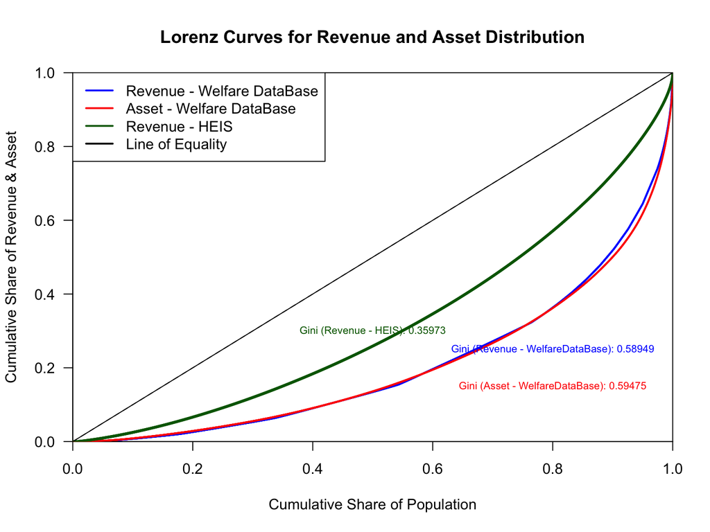

```r
# Compute Lorenz curves
lorenz_revenue <- Lc(Revenue$Total_Revenue)
lorenz_asset <- Lc(Asset$Total_Asset)
lorenz_HEIS <- Lc(combined_monthlyinc$total_netincome_month/combined_monthlyinc$member)

# Compute Gini coefficients
gini_revenue <- round(Gini(Revenue$Total_Revenue), 5)
gini_asset <- round(Gini(Asset$Total_Asset), 5)
gini_HEIS <- round(Gini(combined_monthlyinc$total_netincome_month/combined_monthlyinc$member), 5)

# Plot Lorenz curves
plot(lorenz_revenue,
     main = "Lorenz Curves for Revenue and Asset Distribution",
     xlab = "Cumulative Share of Population",
     ylab = "Cumulative Share of Revenue & Asset",
     col = "blue",
     lwd = 2)

# Add Lorenz curve for Asset
lines(lorenz_asset, col = "red", lwd = 2)

lines(lorenz_HEIS, col = "darkgreen", lwd = 3)

# Add the line of perfect equality
abline(0, 1, col = "black", lty = 2)

# Add legend
legend("topleft",
       legend = c("Revenue - Welfare DataBase", "Asset - Welfare DataBase", "Revenue - HEIS", "Line of Equality"),
       col = c("blue", "red","darkgreen", "black"),
       lty = c(1, 1, 1, 1),
       lwd = c(2, 2, 2, 2),
       bg = "white")
# Add Gini coefficient text directly on the plot
text(0.8, 0.25, paste("Gini (Revenue - WelfareDataBase):", gini_revenue), col = "blue", cex = 0.7)
text(0.8, 0.15, paste("Gini (Asset - WelfareDataBase):", gini_asset), col = "red", cex = 0.7)
text(0.5, 0.30, paste("Gini (Revenue - HEIS):", gini_HEIS), col = "darkgreen", cex = 0.7)
```

The primary reason for the high value of the Gini coefficient is that we used a proxy variable, which may not accurately reflect the distribution of income and wealth in society. Additionally, the estimation of this coefficient was based on only 2% of data from the Iranian Welfare Database, which may not adequately represent the entire population and could be biased.

Since the **Gini Coefficient** for both **income** and **asset** measures is approximately similar, we will only focus on the **Gini Coefficient in Revenue**.

In this part, we focus more precisely on the provincial level to calculate the Gini coefficient for both data sources.

```r
Gini_province_HEIS <- combined_monthlyinc %>%
  group_by(province) %>%
  dplyr::summarize(Gini_Coef_HEIS = Gini(total_netincome_month/member))

Gini_province_welfare <- Revenue %>%
  rename(province = SabteAhval_provincename) %>%
  filter(!is.na(Total_Revenue) & !is.na(province)) %>%
  group_by(province) %>%
  dplyr::summarize(Gini_Coef_Welfare = Gini(Total_Revenue)) %>%
  mutate(province = case_when(
    province == "آذربایجان شرقی" ~ "East Azerbaijan",
    province == "آذربایجان غربی" ~ "West Azerbaijan",
    province == "اردبیل" ~ "Ardabil",
    province == "اصفهان" ~ "Isfahan",
    province == "البرز" ~ "Alborz",
    province == "ایلام" ~ "Ilam",
    province == "بوشهر" ~ "Bushehr",
    province == "تهران" ~ "Tehran",
    province == "خراسان جنوبی" ~ "South Khorasan",
    province == "خراسان رضوی" ~ "Razavi Khorasan",
    province == "خراسان شمالی" ~ "North Khorasan",
    province == "خوزستان" ~ "Khuzestan",
    province == "زنجان" ~ "Zanjan",
    province == "سمنان" ~ "Semnan",
    province == "سیستان وبلوچستان" ~ "Sistan and Baluchestan",
    province == "فارس" ~ "Fars",
    province == "قزوین" ~ "Qazvin",
    province == "قم" ~ "Qom",
    province == "لرستان" ~ "Lorestan",
    province == "مازندران" ~ "Mazandaran",
    province == "مرکزی" ~ "Markazi",
    province == "هرمزگان" ~ "Hormozgan",
    province == "همدان" ~ "Hamadan",
    province == "چهارمحال وبختیاری" ~ "Chaharmahal and Bakhtiari",
    province == "کردستان" ~ "Kurdistan",
    province == "کرمان" ~ "Kerman",
    province == "کرمانشاه" ~ "Kermanshah",
    province == "کهگیلویه وبویراحمد" ~ "Kohgiluyeh and Boyer-Ahmad",
    province == "گلستان" ~ "Golestan",
    province == "گیلان" ~ "Gilan",
    province == "یزد" ~ "Yazd",
    TRUE ~ province)) %>%
  slice(-1)

Gini_province <- Gini_province_HEIS %>%
  left_join(Gini_province_welfare, by = "province") %>%
  arrange(Gini_Coef_HEIS)
kable(Gini_province %>%
    mutate(across(where(is.numeric), ~ formatC(., format = "f", big.mark = ",", digits = 3))), align = "c") %>%
  kable_styling(bootstrap_options = c("striped", "hover", "condensed"), position = "center", full_width = FALSE) %>%
  add_header_above(c("Gini Coefficient (Province Level - Both Data)" = ncol(Gini_province))) %>%
  column_spec(1, background = "brown1") %>%
  column_spec(2, background = "chartreuse1") %>%
  column_spec(3, background = "cadetblue1")
```

| Gini Coefficient (Province Level - Both Data) province | Gini Coefficient (Province Level - Both Data) Gini_Coef_HEIS | Gini Coefficient (Province Level - Both Data) Gini_Coef_Welfare |
| --- | --- | --- |
| Kerman | 0.269 | 0.570 |
| Semnan | 0.283 | 0.564 |
| Kohgiluyeh and Boyer-Ahmad | 0.287 | 0.552 |
| Ilam | 0.288 | 0.582 |
| Gilan | 0.292 | 0.587 |
| Chaharmahal and Bakhtiari | 0.296 | 0.564 |
| Qom | 0.296 | 0.568 |
| West Azerbaijan | 0.302 | 0.573 |
| Alborz | 0.317 | 0.578 |
| Mazandaran | 0.322 | 0.588 |
| Razavi Khorasan | 0.324 | 0.588 |
| Isfahan | 0.327 | 0.574 |
| Bushehr | 0.328 | 0.579 |
| Tehran | 0.330 | 0.595 |
| Lorestan | 0.335 | 0.577 |
| Yazd | 0.338 | 0.551 |
| Zanjan | 0.339 | 0.584 |
| Markazi | 0.342 | 0.565 |
| Khuzestan | 0.343 | 0.571 |
| Ardabil | 0.344 | 0.598 |
| North Khorasan | 0.345 | 0.576 |
| Qazvin | 0.347 | 0.582 |
| East Azerbaijan | 0.347 | 0.592 |
| Hormozgan | 0.356 | 0.600 |
| South Khorasan | 0.357 | 0.568 |
| Kermanshah | 0.360 | 0.591 |
| Golestan | 0.376 | 0.606 |
| Kurdistan | 0.378 | 0.574 |
| Fars | 0.381 | 0.605 |
| Sistan and Baluchestan | 0.398 | 0.584 |
| Hamadan | 0.412 | 0.580 |

```r
# # Arrange the data by descending Total_Revenue
# sorted_Revenue <- Revenue %>%
#   arrange(desc(Total_Revenue))
#
# # Calculate the total revenue once, outside the grouped environment
# total_revenue_pop <- sum(sorted_Revenue$Total_Revenue, na.rm = TRUE)
#
# # Process the data and calculate the top 1% revenue share by province
# top1perc_Revenue <- sorted_Revenue %>%
#   filter(row_number() <= ceiling(0.01 * n())) %>%
#   rename(province = SabteAhval_provincename) %>%
#   filter(!is.na(Total_Revenue) & !is.na(province)) %>%
#   group_by(province) %>%
#   dplyr::summarize(
#     Top1Percent = sum(Total_Revenue, na.rm = TRUE) / total_revenue_pop
#   ) %>%
#   ungroup() %>%
#   mutate(province = case_when(
#     province == "آذربایجان شرقی" ~ "East Azerbaijan",
#     province == "آذربایجان غربی" ~ "West Azerbaijan",
#     province == "اردبیل" ~ "Ardabil",
#     province == "اصفهان" ~ "Isfahan",
#     province == "البرز" ~ "Alborz",
#     province == "ایلام" ~ "Ilam",
#     province == "بوشهر" ~ "Bushehr",
#     province == "تهران" ~ "Tehran",
#     province == "خراسان جنوبی" ~ "South Khorasan",
#     province == "خراسان رضوی" ~ "Razavi Khorasan",
#     province == "خراسان شمالی" ~ "North Khorasan",
#     province == "خوزستان" ~ "Khuzestan",
#     province == "زنجان" ~ "Zanjan",
#     province == "سمنان" ~ "Semnan",
#     province == "سیستان وبلوچستان" ~ "Sistan and Baluchestan",
#     province == "فارس" ~ "Fars",
#     province == "قزوین" ~ "Qazvin",
#     province == "قم" ~ "Qom",
#     province == "لرستان" ~ "Lorestan",
#     province == "مازندران" ~ "Mazandaran",
#     province == "مرکزی" ~ "Markazi",
#     province == "هرمزگان" ~ "Hormozgan",
#     province == "همدان" ~ "Hamadan",
#     province == "چهارمحال وبختیاری" ~ "Chaharmahal and Bakhtiari",
#     province == "کردستان" ~ "Kurdistan",
#     province == "کرمان" ~ "Kerman",
#     province == "کرمانشاه" ~ "Kermanshah",
#     province == "کهگیلویه وبویراحمد" ~ "Kohgiluyeh and Boyer-Ahmad",
#     province == "گلستان" ~ "Golestan",
#     province == "گیلان" ~ "Gilan",
#     province == "یزد" ~ "Yazd",
#     TRUE ~ province)) %>%
#   slice(-1)
#
# # Arrange the data by descending Total_Revenue
# sorted_income_HEIS <- combined_monthlyinc %>%
#   arrange(desc(total_netincome_month))
#
# # Calculate the total revenue once, outside the grouped environment
# total_income_pop <- sum(sorted_income_HEIS$total_netincome_month, na.rm = TRUE)/sum(sorted_income_HEIS$member, na.rm = TRUE)
#
# # Process the data and calculate the top 1% revenue share by province
# top1perc_income <- sorted_income_HEIS %>%
#   filter(row_number() <= ceiling(0.01 * n())) %>%
#   group_by(province) %>%
#   dplyr::summarize(
#     Top1Percent = sum(total_netincome_month, na.rm = TRUE) / total_income_pop) %>%
#   ungroup()
```

In this section, we will save the necessary data frames in CSV format. (Optional)

```r
write_csv(TC_province1, "/Users/mahan/Desktop/Poverty/Atlas Poverty/TC_province1.csv")
write_csv(relative_line, "/Users/mahan/Desktop/Poverty/Atlas Poverty/relative_line.csv")
write_csv(hybrid_poverty_line, "/Users/mahan/Desktop/Poverty/Atlas Poverty/hybrid_poverty_line.csv")
write_csv(income_poverty_line, "/Users/mahan/Desktop/Poverty/Atlas Poverty/income_poverty_line.csv")
write_csv(poverty_gap_index, "/Users/mahan/Desktop/Poverty/Atlas Poverty/poverty_gap_index.csv")
write_csv(MDP_index_province, "/Users/mahan/Desktop/Poverty/Atlas Poverty/MDP_index_province.csv")
write_csv(Gini_province, "/Users/mahan/Desktop/Poverty/Atlas Poverty/Gini_province.csv")
```